# Inter- and intraindividual relationships between vagally-mediated heart rate variability and self-regulatory processes: An ecological momentary assessment

Supplementary material 2: Psychometric and descriptive analyses

Luca Menghini, MS$^1$, Giulia Fuochi, PhD$^2$, Michela Sarlo, PhD$^3$

2023-01-03

$^1$Department of General Psychology, University of Padova, Italy

$^2$Department of Philosophy, Sociology, Pedagogy and Applied Psychology, University of Padova, Italy

$^3$Department of Communication Sciences, Humanities and International Studies, University of Urbino Carlo Bo, Italy

# Aims and content

The present document includes the analytical steps conducted to analyse the psychometric properties and the descriptive statistics of the different types of data collected over three days from a sample of 97 healthy adults that were included in our study. Prior to conduct these analyses, the data were pre-processed as described in the dedicated [pre-processing report](https://luca-menghini.github.io/vmHRV-selfRegulation/2preProcessing/preProcessing.html). The following steps are impemented below:

1. Preprocessed data **reading**
2. Evaluation of the **psychometric properties** of the mood and event ratings via multilevel confirmatory factor analysis and reliability analysis, and computation of the aggregated scores
3. Computation of the **descriptive statistics** for each variable of interest, including the inspection of univariate and bivariate distributions, and the correlation between continuous variables
4. A selection of the potential **confounding variables** to be used as covariates in the following regression analyses (see [dedicated report](https://luca-menghini.github.io/vmHRV-selfRegulation/3regModels/regModels.html))

Here, we remove all objects from the R global environment.

```r
# removing all objets from the workspace
rm(list=ls())
```

The following R packages are used in this document (see References section):

```r
# required packages
packages <- c("lavaan","lme4","ggplot2","gridExtra","reshape2","plyr","MVN","Rmisc","Hmisc")

# generate packages references
knitr::write_bib(c(.packages(), packages),"packagesProc.bib")
```

```
## tweaking Hmisc
```

```r
# # run to install missing packages
# xfun::pkg_attach2(packages, message = FALSE); rm(list=ls())
```

# 1. Data reading

First, we read the pre-processed data files (see details in the [dedicated report](https://luca-menghini.github.io/vmHRV-selfRegulation/2preProcessing/preProcessing.html)).

- `ema` includes HRV, ESM, and PrelQS information with **one row for each measurement** of either HRV (5 ambulatory + 1 lab) or ESM data (1 ‘baseline’ + 5 ambulatory), for a total of 2,037 observations (97 participants x 3 days x 7 occasions).

```r
load("3data/ema_preProcessed.RData")
cat("ema:",nrow(ema),"observations from",nlevels(ema$ID),"participants")
```

```
## ema: 2037 observations from 97 participants
```

```r
head(ema,3)
```

|  | ID | day | within.day | PI | HR | RMSSD | RMSSDcv | nPI | miss | out | nArtefacts | pArtefacts | art10 | inclRate60 | noisyPI | os | RunTimestamp | v1 | v2 | v3 | t1 | t2 | t3 | f1 | f2 | f3 | PE | PE.int | NE | … |
| --- | --- | --- | --- | --- | --- | --- | --- | --- | --- | --- | --- | --- | --- | --- | --- | --- | --- | --- | --- | --- | --- | --- | --- | --- | --- | --- | --- | --- | --- | --- |
| 1 | HRV001 | 1 | 0 | NA | NA | NA | NA | NA | NA | NA | NA | NA | NA | NA | NA | NA | 2018-11-06 10:12:16.000000 | 5 | 3 | 4 | 3 | 5 | 6 | 6 | 6 | 6 | 3 | 2 | 1 | … |
| 2 | HRV001 | 1 | 1 | 648.7515 | 92.86897 | 25.77279 | 3.972675 | 183 | 0 | 0 | 8 | 4.371585 | 0 | 0 | 0 | Android | 2018-11-06 11:38:33.269885 | 5 | 4 | 4 | 3 | 3 | 3 | 6 | 3 | 6 | 1 | 1 | 2 | … |
| 3 | HRV001 | 1 | 2 | 655.0000 | 91.85054 | 23.27229 | 3.553021 | 175 | 0 | 0 | 5 | 2.857143 | 0 | 0 | 0 | Android | 2018-11-06 12:44:45.654594 | 4 | 4 | 3 | 2 | 3 | 3 | 5 | 3 | 5 | 2 | 2 | 1 | … |

- `between` includes all collected variables, with one row for each participant, for a total of 97 observations. HRV, ESM, GNG, and BLOCK data are averaged by participant.

```r
load("3data/between_preProcessed.RData")
cat("between:",nrow(between),"observations from",nlevels(between$ID),"participants")
```

```
## between: 97 observations from 97 participants
```

```r
head(between,3)
```

|  | ID | time | age | gender | BMI | drugs | dysfun | postponed | PI.cm | HR.cm | RMSSD.cm | RMSSD.cMed | RMSSDcv.cm | RMSSDcv.cMed | nArtefacts.cm | inclRate60 | noisyPI | cLessResp1 | cLessResp2 | smoker | os | RT.cm | Go.ACC.cm | NoGo.ACC.cm | RT.sd.cm | ICV.cm |
| --- | --- | --- | --- | --- | --- | --- | --- | --- | --- | --- | --- | --- | --- | --- | --- | --- | --- | --- | --- | --- | --- | --- | --- | --- | --- | --- |
| 1 | HRV001 | 2018-11-07 11:32:45 | 25 | M | 19.23947 | 0 | 0 | 0 | 675.2643 | 90.23650 | 30.59367 | 29.12373 | 4.458349 | 4.362530 | 2.833333 | 0 | 0 | 0 | 0 | 0 | Android | 313.7193 | 0.9897119 | 0.8086420 | 38.04834 | 0.1211802 |
| 2 | HRV002 | 2018-11-08 00:52:05 | 28 | M | 22.72044 | 0 | 0 | 0 | 687.4211 | 88.18662 | 32.73786 | 33.64712 | 4.755902 | 4.658098 | 9.800000 | 0 | 0 | 0 | 0 | 1 | Android | 319.1620 | 0.9650206 | 0.7098765 | 57.84091 | 0.1817719 |
| 3 | HRV003 | 2018-11-06 19:07:25 | 22 | F | 26.64360 | 0 | 0 | 0 | 798.5118 | 76.66033 | 51.70056 | 54.11966 | 6.331069 | 6.437853 | 11.200000 | 1 | 0 | 0 | 0 | 0 | Android | 313.7914 | 0.9567901 | 0.5987654 | 54.11107 | 0.1725476 |

- `gng` includes all collected variables, with one row for each trial of the Go/No-go task, for a total of 62,856 observations (i.e., 97 participants x 3 days x 2 blocks x 108 trials). HRV data is included only for the segments recorded in the lab (within.day = 6), whereas ESM information is included only as the last ESM data entry (within.day = 5`).

```r
load("3data/gng_preProcessed.RData")
cat("gng:",nrow(gng),"observations from",nlevels(gng$ID),"participants")
```

```
## gng: 62856 observations from 97 participants
```

```r
head(gng,3)
```

|  | ID | day | block | SessionDate | SessionTime | TrialType | letter | Jitter | ACC | RT | PI | HR | RMSSD | RMSSDcv | nPI | miss | out | nArtefacts | pArtefacts | art10 | inclRate60 | noisyPI | os | gender | RunTimestamp | v1 | v2 | v3 | t1 | … |
| --- | --- | --- | --- | --- | --- | --- | --- | --- | --- | --- | --- | --- | --- | --- | --- | --- | --- | --- | --- | --- | --- | --- | --- | --- | --- | --- | --- | --- | --- | --- |
| 1 | HRV001 | 1 | 1 | 2018-11-06 16:17:55 | 1970-01-01 16:17:55 | Go | L | 200 | 1 | 343 | 831.271 | 72.54979 | 49.26012 | 5.92588 | 149 | 0 | 0 | 0 | 0 | 0 | 0 | 0 | Android | M | 2018-11-06 16:09:16.716757 | 3 | 4 | 2 | 3 | … |
| 2 | HRV001 | 1 | 1 | 2018-11-06 16:17:55 | 1970-01-01 16:17:55 | No-go | T | 200 | 1 | 0 | 831.271 | 72.54979 | 49.26012 | 5.92588 | 149 | 0 | 0 | 0 | 0 | 0 | 0 | 0 | Android | M | 2018-11-06 16:09:16.716757 | 3 | 4 | 2 | 3 | … |
| 3 | HRV001 | 1 | 1 | 2018-11-06 16:17:55 | 1970-01-01 16:17:55 | Go | L | 0 | 1 | 328 | 831.271 | 72.54979 | 49.26012 | 5.92588 | 149 | 0 | 0 | 0 | 0 | 0 | 0 | 0 | Android | M | 2018-11-06 16:09:16.716757 | 3 | 4 | 2 | 3 | … |

- `block` includes all collected variables, with one row for each block of the go/no-go task, for a total of 582 observations (i.e., 97 participants x 3 days x 2 blocks). Again, `HRV` data is included only for the segments recorded in the lab (`within.day` = 6), whereas `ESM` information is included only as the last ESM data entry (`within.day = 5`).

```r
load("3data/block_preProcessed.RData")
cat("block:",nrow(block),"observations from",nlevels(block$ID),"participants")
```

```
## block: 582 observations from 97 participants
```

```r
head(block,3)
```

|  | ID | day | block | Go.ACC | NoGo.ACC | RT | RT.sd | ICV | time.HRV | PI | HR | RMSSD | RMSSDcv | nPI | miss | out | nArtefacts | pArtefacts | art10 | inclRate60 | noisyPI | os | gender | time.ESM | RunTimestamp | v1 | v2 | v3 | t1 | … |
| --- | --- | --- | --- | --- | --- | --- | --- | --- | --- | --- | --- | --- | --- | --- | --- | --- | --- | --- | --- | --- | --- | --- | --- | --- | --- | --- | --- | --- | --- | --- |
| 1 | HRV001 | 1 | 1 | 0.9876543 | 0.8888889 | 334.3875 | 41.39360 | 0.1237893 | 6 | 831.271 | 72.54979 | 49.26012 | 5.925880 | 149 | 0 | 0 | 0 | 0.0000000 | 0 | 0 | 0 | Android | M | 5 | 2018-11-06 16:09:16.716757 | 3 | 4 | 2 | 3 | … |
| 2 | HRV001 | 1 | 2 | 0.9876543 | 0.7777778 | 310.6500 | 35.89792 | 0.1155574 | 6 | 831.271 | 72.54979 | 49.26012 | 5.925880 | 149 | 0 | 0 | 0 | 0.0000000 | 0 | 0 | 0 | Android | M | 5 | 2018-11-06 16:09:16.716757 | 3 | 4 | 2 | 3 | … |
| 3 | HRV001 | 2 | 1 | 1.0000000 | 0.7777778 | 319.0988 | 42.37352 | 0.1327912 | 6 | 651.014 | 92.44653 | 29.90505 | 4.593611 | 188 | 0 | 0 | 1 | 0.5319149 | 0 | 0 | 0 | Android | M | 5 | 2018-11-07 16:13:23.439549 | 5 | 5 | 4 | 5 | … |

# 2. Psychometrics

Second, we evaluate the psychometric properties of the considered mood and event ratings. The following packages and function are used to optimize psychometric analyses.

```r
library(lavaan); library(lme4); library(ggplot2); library(dplyr); library(reshape2); library(plyr); library(MVN)
library(MuMIn); library(gridExtra); library(tcltk)
```

**`itemICC`**

```r
itemsICC <- function(data,items,output="text",digits=3){ require(lme4)

  # empty data.frame of results
  res <- data.frame(item=NA,icc=NA)

  # multilevel model and variance partitioning for each item
  for(i in 1:length(items)){
    m <- lmer(formula=gsub("d1",items[i],"d1~(1|ID)"),data=data) # mlv model with random intercept for participants' ID
    out <- round(as.data.frame(VarCorr(m))[1,4]/ # computing ICC as VAR_between / (VAR_between + VAR_within)
                   (as.data.frame(VarCorr(m))[1,4]+as.data.frame(VarCorr(m))[2,4]),digits)

    # textual output or data.frame
    if(output=="text"){cat(items[i],"ICC =",out,"\n")

      # data.frame output
      } else { res <- rbind(res,cbind(item=items[i],icc=out)) }}
  if(output!="text"){ return(res) }}
```

**`corr.matrices`**

```r
corr.matrices <- function(data,vars,matrix.type=c("pooled","between","within"),ID="ID"){
  require(ggplot2); require(reshape2); require(plyr)

  # setting ID name
  colnames(data)[which(colnames(data)==ID)] <- "ID"

  # function that computes and plots the correlations
  cm <- function(data,vars){
    c <- melt(cor(data[,which(colnames(data)%in%vars)],data[,which(colnames(data)%in%vars)],
                  use="complete.obs",method="pearson")) # listwise deletion
    ggplot(c,aes(x=Var1,y=Var2,fill=value)) + geom_tile() + # plotting heat diagram
      geom_text(aes(x=Var1,y=Var2,label=round(value,2)),color="black",size=5) + labs(x="",y="")+
      scale_fill_gradient2(low="darkblue",high="#f03b20",mid="white",midpoint=0,limit=c(-1,1),space="Lab",
                           name="Pearson\nCorrelation",guide="legend",breaks=round(seq(1,-1,length.out = 11),2),
                           minor_breaks=round(seq(1,-1,length.out = 11),2)) + theme(text=element_text(face="bold",size=12)) }

  # pooled correlation matrix (as the ratings were independent)
  if(matrix.type=="pooled"){
    cm(data,vars) + ggtitle(paste("Pooled correlation matrix, N =",nrow(na.omit(ema[,vars]))))

  } else {
    # computing individual means
    between <- data[!duplicated(data$ID),]
    for(Var in vars){
      means <- aggregate(data[,Var]~data[,"ID"],FUN="mean",na.action=na.omit)
      colnames(means) <- c("ID",paste(Var,".cm",sep=""))
      between <- join(between,means,by="ID",type="left") }

    # level-2 matrix (averaged scores by participant)
    if(matrix.type=="between"){
      cm(between,paste(vars,".cm",sep="")) + ggtitle(paste("Level-2 correlation matrix, N =",nrow(between)))

    # level-1 matrix (mean-centered scores)
    } else if(matrix.type=="within"){

      # computing mean-centered scores
      data <- join(data,between[,c("ID",paste(vars,".cm",sep=""))],by="ID",type="left") # merging data with individual means
      for(Var in vars){ data[,paste(Var,".mc",sep="")] <- data[,Var] - data[,paste(Var,".cm",sep="")] } # person-mean-centering

      # plotting
      cm(data,paste(vars,".mc",sep="")) + ggtitle(paste("Level-1 correlation matrix, N =",
                                                        nrow(na.omit(data[,paste(Var,".mc",sep="")])))) }}}
```

Computes and plots the pooled, between-subjects, and within-subject correlation matrix of item ratings.

**`loadings()`**

```r
#' @title Summarizing standardized loadings from a multilevel CFA model
#' @param model = multilevel CFA model.
#' @param st = Character indicating the standardization level of loadings: "st.all" or "st.lv".
loadings <- function(model=NA,st="st.all"){ require(lavaan)
  if(st=="st.all"){ LOADs <- standardizedsolution(model)
  } else if(st=="st.lv"){ LOADs <- standardizedsolution(model,type="st.lv")
  } else{ LOADs <- parameterestimates(model) }
  return(LOADs[LOADs$op=="=~",])}
```

Print the standardized factor loadings of an ordinary or a multilevel CFA model.

**`fit.ind()`**

```r
fit.ind <- function(model=NA,from_summary=FALSE,type="multilevel",models.names=NA,infocrit=TRUE,digits=3,
                    fits=c("npar","chisq","df","rmsea","cfi","srmr_within","srmr_between")){ require(lavaan); require(MuMIn)
  # removing level-specific fit indices when model is "monolevel"
  if(type=="monolevel"){
      fits <- gsub("srmr_within","srmr",fits)
      fits <- fits[fits!="srmr_between"] }
  if(from_summary==FALSE){
    # returning data.frame of models fit indices when more than one model is considered
    if(length(model)>1){
      fit.indices <- fitmeasures(model[[1]])[fits]
      for(i in 2:length(model)){
        fit.indices <- rbind(fit.indices,fitmeasures(model[[i]])[fits]) }
      if(infocrit==TRUE){
        fit.indices <- cbind(fit.indices,
                             AICw=Weights(sapply(model,AIC)),BICw=Weights(sapply(model,BIC)))  }
      if(!is.na(models.names[1])){ row.names(fit.indices) <- models.names }
      fit.indices <- round(as.data.frame(fit.indices),digits)
      return(fit.indices[order(fit.indices$rmsea),])
      } else { return(round(as.data.frame(fitmeasures(model)[fits]),2)) }

    } else { # in some cases the fit indices are available only from the model's summary
      quiet <- function(fit) { # this was written by Alicia FRANCO MARTÍNEZ on the lavaan Google group
        sink(tempfile())
        on.exit(sink())
        invisible(summary(fit, standardized = TRUE, fit.measures=TRUE))
        }
      sum <- quiet(model)
      fit.indices <- sum$FIT[fits]
      return(round(as.data.frame(fit.indices[order(fit.indices$rmsea),]),digits))}}
```

Prints fit indices of one or more CFA models. Note: According to the criteria proposed by Hu and Bentler (1999), we consider RMSEA ≤ .06, CFI ≥ .95, and SRMR ≤ .08 as indicative of adequate fit.

**`mcfa.Huang()`**

```r
mcfa.Huang<-function(gp,dat){
  dat1<-dat[complete.cases(dat),]
  g<-dat1[,gp] #grouping
  freq<-data.frame(table(g))
  gn<-grep(gp,names(dat1)) #which column number is the grouping var
  dat2<-dat1[,-gn] #raw only
  G<-length(table(g))
  n<-nrow(dat2)
  k<-ncol(dat2)
  scaling<-(n^2-sum(freq$Freq^2)) / (n*(G-1))
  varn<-names(dat1[,-gn])
  ms<-matrix(0,n,k)
  for (i in 1:k){
    ms[,i]<-ave(dat2[,i],g)
  }
  cs<-dat2-ms #deviation matrix, centered scores
  colnames(ms)<-colnames(cs)<-varn
  b.cov<-(cov(ms) * (n - 1))/(G-1) #group level cov matrix
  w.cov<-(cov(cs) * (n - 1))/(n-G) #individual level cov matrix
  pb.cov<-(b.cov-w.cov)/scaling #estimate of pure/adjusted between cov matrix
  w.cor<-cov2cor(w.cov) #individual level cor matrix
  b.cor<-cov2cor(b.cov) #group level cor matrix
  pb.cor<-cov2cor(pb.cov) #estimate of pure between cor matrix
  icc<-round(diag(pb.cov)/(diag(w.cov)+diag(pb.cov)),3) #iccs
  return(list(b.cov=b.cov,pw.cov=w.cov,ab.cov=pb.cov,pw.cor=w.cor,
              b.cor=b.cor,ab.cor=pb.cor,
              n=n,G=G,c.=scaling,sqc=sqrt(scaling),
              icc=icc,dfw=n-G,dfb=G)) }
```

Generate the pooled within-subject covariance matrix. Note: function created by Francis L. Huang (University of Missouri), available from https://francish.netlify.app/

**`influential.analysis()`**

```r
#' @title Influential analysis
#' @param data = data.frame used by the model.
#' @param cluster = Character. Variable name in the data frame defining the cluster in a two-level dataset.
#' @param parameter = Character. "var" for estimated variances, "load" for loadings.
#' @param st = Character indicating the standardization level of loadings: "st.all" or "st.lv".
#' @param n.items = Integer. Number of observed variables considered by the model.
#' @param item.labels = Character vector indicating the labels of the considered observed variables.
#' @param m = Character string specifying the model using the lavaan synthax.
influential.analysis <- function(data=NA,cluster="ID",parameter="var",st="st.all",
                                 n.items=9,item.labels=c("v1", "v2", "v3", "t1", "t2", "t3", "f1", "f2","f3"),
                                 m = 'level: 1
                                      hedTone_W =~ v1 + v2 + v3
                                      Calmness_W =~ t1 + t2 + t3
                                      enArousal_W =~ f1 + f2 + f3
                                      level: 2
                                      hedTone_B =~ v1 + v2 + v3
                                      Calmness_B =~ t1 + t2 + t3
                                      enArousal_B =~ f1 + f2 + f3'){ require(lavaan); require(tcltk)
  # storing results on the whole sample
  m.res <- cfa(model=m,data=data,cluster=cluster,std.lv=TRUE)

  if(parameter=="var"){
    lv1 <- parameterestimates(m.res)[parameterestimates(m.res)$op=="~~" &
                                       nchar(parameterestimates(m.res)$lhs)==2 &
                                       parameterestimates(m.res)$level==1,"est"]
    lv2 <- parameterestimates(m.res)[parameterestimates(m.res)$op=="~~" &
                                       nchar(parameterestimates(m.res)$lhs)==2 &
                                       parameterestimates(m.res)$level==2,"est"]
  } else if(parameter=="load"){
    if(st=="st.all"){
    lv1 <- standardizedsolution(m.res)[standardizedsolution(m.res)$op=="=~",
                                       "est.std"][1:n.items]
    lv2 <- standardizedsolution(m.res)[standardizedsolution(m.res)$op=="=~",
                                       "est.std"][(n.items+1):(n.items*2)]
  } else if(st=="st.lv"){
    lv1 <- standardizedsolution(m.res,type="st.lv")[standardizedsolution(m.res,type="st.lv")$op=="=~",
                                       "est.std"][1:n.items]
    lv2 <- standardizedsolution(m.res,type="st.lv")[standardizedsolution(m.res,type="st.lv")$op=="=~",
                                       "est.std"][(n.items+1):(n.items*2)]
  } else{
    lv1 <- parameterestimates(m.res)[parameterestimates(m.res)$op=="=~",
                                       "est.std"][1:n.items]
    lv2 <- parameterestimates(m.res)[parameterestimates(m.res)$op=="=~",
                                       "est.std"][(n.items+1):(n.items*2)]
  }
    }

  # dataframe storing results
  parameters <- data.frame(ID=rep("all",n.items),
                           lv1 = lv1,
                           lv2 = lv2,
                           neg.var=rep(1,n.items))
  if(!any(diag(lavInspect(m.res,"est")[["within"]][["theta"]]) < 0) &
     !any(diag(lavInspect(m.res,"est")[["ID"]][["theta"]]) < 0)){
    parameters[1:n.items,"neg.var"] <- 0 }

  # replicate parameters estimation by excluding any participant one-by-one
  IDs <- levels(as.factor(as.character(data$ID)))
  pb <- tkProgressBar("Modeling", "Data modeling",0, 100, 50) # progress bar
  for(ID in IDs){ info <- sprintf("%d%% done", round(which(IDs==ID)/length(IDs)*100))
    setTkProgressBar(pb, round(which(IDs==ID)/length(IDs)*100), sprintf("Data modeling", info), info)
    m.res <- cfa(model=m,data=data[data$ID!=ID,],cluster=cluster,std.lv=TRUE)

    if(parameter=="var"){
    lv1 <- parameterestimates(m.res)[parameterestimates(m.res)$op=="~~" &
                                       nchar(parameterestimates(m.res)$lhs)==2 &
                                       parameterestimates(m.res)$level==1,"est"]
    lv2 <- parameterestimates(m.res)[parameterestimates(m.res)$op=="~~" &
                                       nchar(parameterestimates(m.res)$lhs)==2 &
                                       parameterestimates(m.res)$level==2,"est"]
  } else if(parameter=="load"){
    if(st=="st.all"){
    lv1 <- standardizedsolution(m.res)[standardizedsolution(m.res)$op=="=~",
                                       "est.std"][1:n.items]
    lv2 <- standardizedsolution(m.res)[standardizedsolution(m.res)$op=="=~",
                                       "est.std"][(n.items+1):(n.items*2)]
  } else if(st=="st.lv"){
    lv1 <- standardizedsolution(m.res,type="st.lv")[standardizedsolution(m.res,type="st.lv")$op=="=~",
                                       "est.std"][1:n.items]
    lv2 <- standardizedsolution(m.res,type="st.lv")[standardizedsolution(m.res,type="st.lv")$op=="=~",
                                       "est.std"][(n.items+1):(n.items*2)]
  } else{
    lv1 <- parameterestimates(m.res)[parameterestimates(m.res)$op=="=~",
                                       "est.std"][1:n.items]
    lv2 <- parameterestimates(m.res)[parameterestimates(m.res)$op=="=~",
                                       "est.std"][(n.items+1):(n.items*2)] }}

    # negative estimated variances
    if(!any(diag(lavInspect(m.res,"est")[["within"]][["theta"]]) < 0) &
     !any(diag(lavInspect(m.res,"est")[["ID"]][["theta"]]) < 0)){
    neg.Var <- 0 } else { neg.Var <- 1 }

    # storing information
    parameters <- rbind(parameters,
                        data.frame(ID=rep(ID,n.items),
                                   lv1=lv1,lv2=lv2,
                                   neg.var = rep(neg.Var,n.items)))}
  close(pb)
  parameters$X <- rep(item.labels,length(IDs)+1)
  parameters <- parameters[,c("ID","X","lv1","lv2","neg.var")]

  if(parameter=="var"){
    cat("Negative variance estimated on level 2 for the following items:",
      levels(as.factor(as.character(parameters[parameters$lv2<0,"X"]))),
      "\nNegative variance estimated on level 1 for the following items:",
      levels(as.factor(as.character(parameters[parameters$lv1<0,"X"]))),sep=" ")}
  return(parameters)}
```

fits a MCFA model on several subsamples obtained by removing each participant (cluster) one by one, and save the parameters (either item loadings or item residual variances) estimated in each subsample

**`plot.influential()`**

```r
#' @title Plotting results of influential analysis
#' @param data = data.frame generated by the influential.analysis function.
#' @param parameter = Character. "var" for estimated variances, "load" for loadings.
#' @param variable = Character indicating the name of the observed variable to be plotted.
#' @param level = Integer indicating if focusing on level 1 or 2 (default).
#' @param threshold_lower = Numeric. Threeshold below which the participants'IDs are showed.
#' @param threshold_upper = Numeric. Threeshold above which the participants'IDs are showed.
plot.influential <- function(data,parameter="var",variable,level=2,threshold_lower=NA,threshold_upper=NA){ require(ggplot2)

  if(parameter=="var"){ par <- "variance"} else { par = "loading" }
  if(level==2){ colnames(data)[colnames(data)=="lv2"] <- "par"
  } else { colnames(data)[colnames(data)=="lv1"] <- "par" }

  p <- ggplot(data[data$X==variable,],aes(ID,par))+
  geom_point()+ggtitle(paste(variable,par,"on level",level))+
  geom_point(data=data[data$X==variable & data$ID=="all",],colour="blue",size=5)+
  # geom_point(data=data[data$X==variable & data$par<0,],colour="red")+
  geom_point(data=data[data$X==variable & data$neg.var==1,],colour="red")+
  theme(axis.text.x = element_blank()) + xlab("")

    if(!is.na(threshold_lower) & is.na(threshold_upper)){
      p <- p + geom_text(data=data[data$X==variable &
                                     data$par < threshold_lower,],
                         aes(label=substr(ID,5,6)),nudge_x=-2,size=3)
      } else if(is.na(threshold_lower) & !is.na(threshold_upper)){
        p <- p + geom_text(data=data[data$X==variable &
                                       data$par > threshold_upper,],
                           aes(label=substr(ID,5,6)),nudge_x=-2,size=3)
        } else if(!is.na(threshold_lower) & !is.na(threshold_upper)){
          p <- p + geom_text(data=data[data$X==variable &
                                         (data$par > threshold_upper |
                                            data$par < threshold_lower),],
                           aes(label=substr(ID,5,6)),nudge_x=-2,size=3) }

  return(p) }
```

plots the parameters obtained with the `influential.analysis()` function

**`check.influential()`**

```r
#' @title Inspecting changes in parameters after the removal of influential cases
#' @param model = MCFA model fitted with lavaan.
#' @param data = data.frame generated by the influential.analysis function.
#' @param parameter = Character. Identification codes of participants to be excluded.
#' @param level = Numeric. 1 = within, 2 = between (default).
check.influential <- function(model,data,IDs,level=2){ require(lavaan); require(ggplot2)

  # excluding participants
  data2 <- data
  for(ID in levels(as.factor(data$ID))){
    if(any(IDs==ID)){ data2 <- data2[data2$ID!=ID,] }}

  # updating model
  model2 <- update(model,data=data2)

  # standardized loadings
  load1 <- standardizedsolution(model)[standardizedsolution(model)$op=="=~",]
  load2 <- standardizedsolution(model2)[standardizedsolution(model2)$op=="=~",]

  # data.frame of loadings
  loads <- data.frame(inclusion=as.factor(c(rep("IN",nrow(load1)),rep("OUT",nrow(load1)))), # inclusion
                      load=as.factor(paste(load1[,"rhs"],c(rep("w",nrow(load1)/2),rep("b",nrow(load1)/2)),sep="_")),
                      loading=c(load1[,"est.std"],load2[,"est.std"]))

  ggplot(loads,aes(x=inclusion,y=loading,color=load)) + geom_point() + geom_line(aes(group=load))
  }
```

visualizes the changes in parameters estimated with and without one or more participants

**`plot.traj()`**

```r
#' @title Plotting trajectories of Mood items scores of single participants
#' @param data = data.frame generated by the influential.analysis function.
#' @param ID = Character. Identification code for the selected participant.
plot.traj <- function(data,var="Mood",ID){ require(ggplot2); require(gridExtra)

    # Negative Valence
  p1 <- ggplot(data[data$ID==ID,],aes(x=within.day,y=v1))+
    geom_line(aes(y=4),linetype=2) + geom_smooth(se=FALSE,span=0.7,color="lightblue")+
      geom_smooth(aes(y=v2),se=FALSE,span=0.7,color="blue")+
      geom_smooth(aes(y=v3),se=FALSE,span=0.7,color="darkblue")+
      facet_wrap("day",strip.position="right")+
      ggtitle(paste("Hedonic Tone items in participant",ID))+ylab("")+xlab("")+
      scale_x_continuous(breaks=1:7)+scale_y_continuous(breaks=1:7)+
      theme(axis.text = element_text(size=5),strip.background = element_rect(colour=factor(data$ID)))

    # tense arousal
  p2 <- ggplot(data[data$ID==ID,],aes(x=within.day,y=t1))+
    geom_line(aes(y=4),linetype=2) + geom_smooth(se=FALSE,span=0.7,color="salmon")+
      geom_smooth(aes(y=t2),se=FALSE,span=0.7,color="red")+
      geom_smooth(aes(y=t3),se=FALSE,span=0.7,color="darkred")+
      facet_wrap("day",strip.position="right")+
      ggtitle(paste("Calmness items in participant",ID))+ylab("")+xlab("")+
      scale_x_continuous(breaks=1:7)+scale_y_continuous(breaks=1:7)+
      theme(axis.text = element_text(size=5),strip.background = element_rect(colour=factor(data$ID)))

    # fatigue
  p3 <- ggplot(data[data$ID==ID,],aes(x=within.day,y=f1))+
    geom_line(aes(y=4),linetype=2) + geom_smooth(se=FALSE,span=0.7,color="yellow")+
      geom_smooth(aes(y=f2),se=FALSE,span=0.7,color="salmon")+
      geom_smooth(aes(y=f3),se=FALSE,span=0.7,color="orange")+
      facet_wrap("day",strip.position="right")+
      ggtitle(paste("Energetic Arousal items in participant",ID))+ylab("")+xlab("")+
      scale_x_continuous(breaks=1:7)+scale_y_continuous(breaks=1:7)+
      theme(axis.text = element_text(size=5),strip.background = element_rect(colour=factor(data$ID)))

  if(var=="Mood"){ grid.arrange(p1,p2,p3,nrow=3)
    } else if(var=="HT"){ p1 }else if(var=="CA"){ p2 } else{ p3 }}
```

plots the item scores’ temporal trajectories of a given participant

**`MCFArel`**

```r
#' @title Computing composite reliability index from a MCFA model
#' @param fit = multileve CFA model.
#' @param level = level of interest (either 1 or 2)
#' @param items = numeric string indicating the items of interest (e.g., 1:3 for items 1, 2 and 3)
#' @param item.labels = character string indicating the names of the items of interest
MCFArel <- function(fit,level,items,item.labels){ require(lavaan)
  if(level==1){
    sl <- standardizedsolution(fit)[1:(nrow(standardizedSolution(fit))/2),] # pars within
  } else if(level==2){
    sl <- standardizedsolution(fit)[(nrow(standardizedSolution(fit))/2):nrow(standardizedsolution(fit)),] # pars between
  } else { stop("Error: level can be either 1 or 2") }
  sl <- sl$est.std[sl$op == "=~"][items] # standardized loadings of the selected items
  names(sl) <- item.labels # item names
  re <- 1 - sl^2 # residual variances of items

  omega <- sum(sl)^2 / (sum(sl)^2 + sum(re)) # composite reliability index
  return(round(omega,2))}
```

Compute level-specific indices of composite reliability from a MCFA model (see Geldhof et al., 2014).

## 2.1. Mood

Mood was measured using the Italian adaptation of the Multidimensional Mood Questionnaire (MDMQ) (Wilhelm & Schoebi, 2007; Menghini et al., 2022), using 9 bipolar items to measure three hypothesized correlated dimension, namely Hedonic Tone, Calmness, and Energetic Arousal. Item scores were recoded so that higher scores indicate more positive ratings. Here, we prepare the data to be used in the analysis by selecting the dataset with all cases with complete responses to any mood item, which we call `Mood`.

```r
# selecting mood item labels
mood <- c("v1","v2","v3", # hedonic tone
          "t1","t2","t3", # calmness
          "f1","f2","f3") # energetic arousal

# selecting dataset of complete responses (listwise deletion)
Mood <- na.omit(ema[,c("ID",mood)])
cat("Analysing",nrow(Mood),"complete responses from",nlevels(as.factor(as.character(Mood$ID))),"participants")
```

```
## Analysing 1600 complete responses from 97 participants
```

### 2.1.1. Item descriptives

First, we consider descriptive statistics in raw item scores, in terms of score distribution, ICC, and correlations.

#### 2.1.1.1. Score distributions

First, we inspect the score distribution of each mood item using the `MVN` package. We can note that mood items are **quite normally distributed**, with a little skewness on the left (especially for items `t1`, `t2`, and `t3`). Although Mood items show the typical “discrete” patterns of ordinal scales, no drastic deviations from normality are detected and we are confident using them for confirmatory factor analysis (see below).

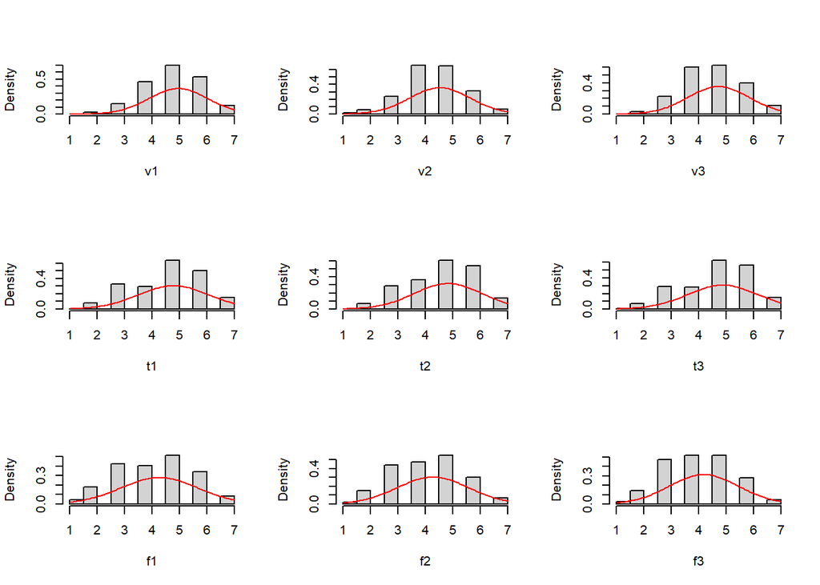

```
## $<NA>
## NULL
```

```r
mvn(data=Mood[,mood],univariatePlot="histogram")[4] # histogram mood
```

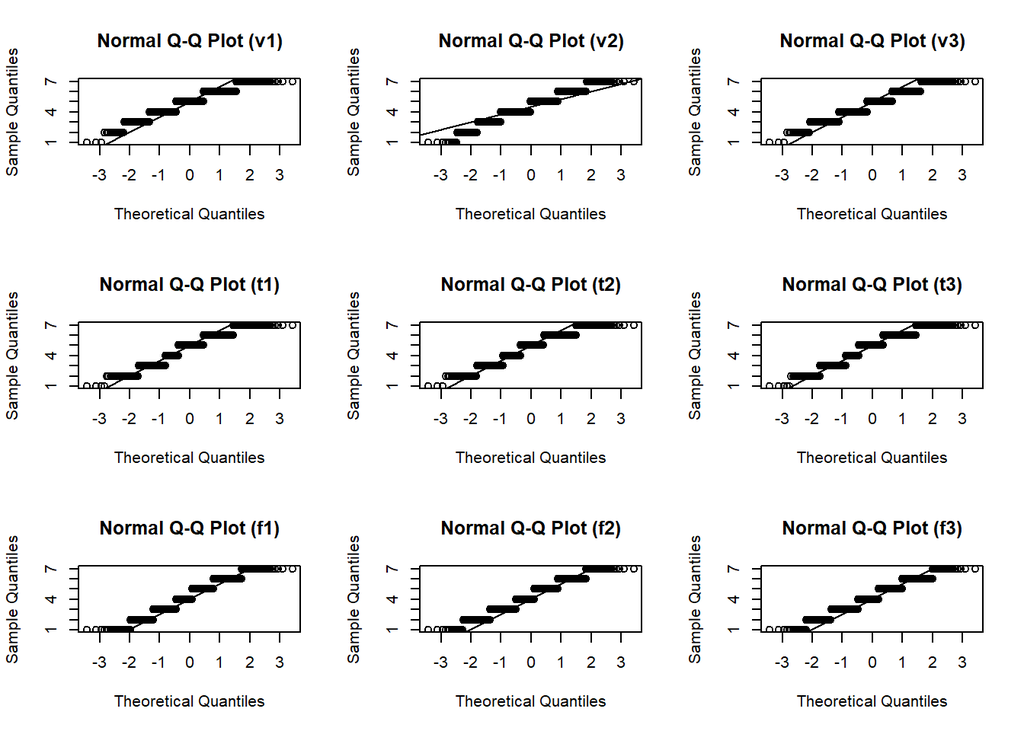

```
## $<NA>
## NULL
```

```r
mvn(data=Mood[,mood],univariatePlot="qqplot")[4] # qqnorm mood
```

#### 2.1.1.2. ICC

```r
itemsICC(data=Mood,items=mood)
```

```
## v1 ICC = 0.416
## v2 ICC = 0.396
## v3 ICC = 0.403
## t1 ICC = 0.384
## t2 ICC = 0.372
## t3 ICC = 0.384
## f1 ICC = 0.347
## f2 ICC = 0.314
## f3 ICC = 0.353
```

#### 2.1.1.3. Correlations

Third, we visualize the correlation matrices of mood item scores with the `corr.matrices` function showed above. Three matrices are generated, all showing plausible values coherently with the hypothesized measurement model, and proportional across matrices (suggesting that cross-level invariance is plausible):

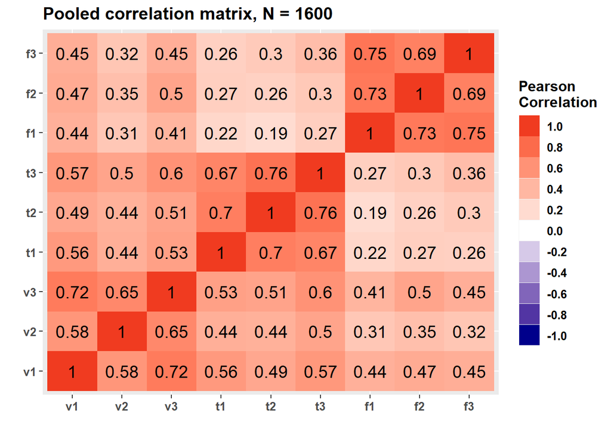

```r
corr.matrices(data=ema,vars=mood,matrix.type="pooled")
```

2. The **level-2** matrix showing the correlations among the aggregated item scores, computed as the mean score for each participant, and thus reflecting the **between-individual covariance** between item scores. We can note that the correlations are quite proportional to those shown in the pooled matrix above, but higher in magnitude. This is due to the measurement error being lower at the between level (see Hox, 2010).

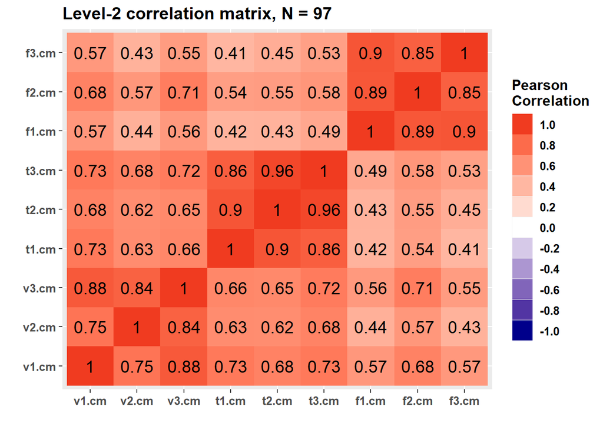

```r
corr.matrices(data=ema,vars=mood,matrix.type="between")
```

3. The **level-1** matrix showing the correlations among the person-mean-centered item scores, computed by subtracting the participant’s mean from each of her ratings, and thus reflecting the **within-individual covariance** between item scores. We can note that the correlations are quite proportional to those shown in the pooled matrix above, but lower in magnitude. This is due to the measurement error being higher at the within level (see Hox, 2010).

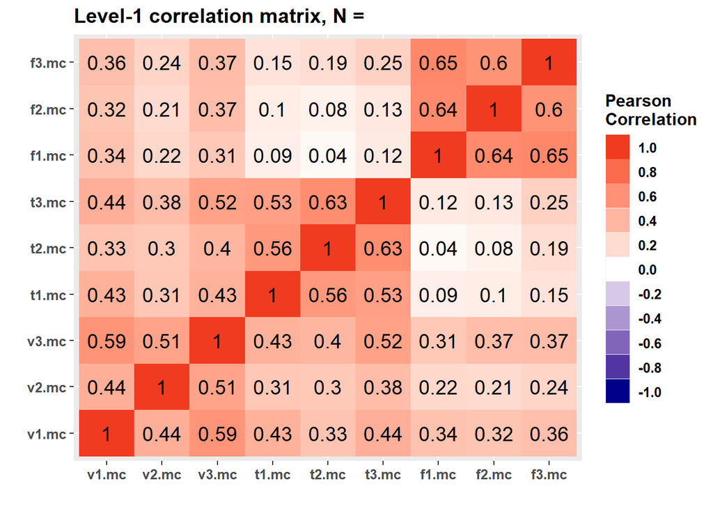

```r
corr.matrices(data=ema,vars=mood,matrix.type="within")
```

### 2.1.2. Multilevel CFA

Second, a **multilevel confirmatory factor analysis** (MCFA) is performed on mood item ratings to evaluate the validity of the hypothesized measurement model (i.e., assuming three correlated factors at both levels) and the cross-level isomorphism of our mood measure.

The following analytical pipeline is implemented:

1. The hypothesized and alternative **multilevel models** are specified, in addition to a set of **preliminary benchmark models** (following Hox, 2010, chapter 14) and models assuming **cross-level invariance** (following Jak & Jorgensen, 2017)
2. Potential problems of non-convergence or Heywood cases (**improper solutions**) are handled
3. A **model comparison** is performed between the specified models using fit indices and information criteria
4. Standardized and unstandardized **factor loadings** estimated by the selected model are inspected

#### 2.1.2.1. Benchmark models

Here, we conduct the preliminary steps suggested by Hox (2010, chapter 14). Similar to what recommended by Muthén (1994), the idea is to specify a set of models to separately assess the factor structure at level 1 (within) and level 2 (between), and to compare those models with the hypothesized multilevel model.

##### Within

The first step evaluates the **within-cluster factor structure**. Following Muthén (1994), we conduct a conventional (one-level) CFA of the **pooled within-cluster covariance matrix** `poolCov`, obtained with a function created by Huang (2018). We can note that all standardized loadings estimated from the pooled within-cluster covariance matrix are significant and equal to or higher than .60. Item `v2` shows the lowest loading (.60), whereas the highest loading is showed by `f1` (.82). The model shows roughly acceptable fit indices, suggesting that **the within-cluster structure holds**.

```r
# poolend covariance matrix (using function by Huang)
poolCov <- mcfa.Huang(dat=Mood,gp="ID")$pw.cov

# one-level model on the pooled within-cluster matrix
m.withinPool_Mood <- cfa('hedTone =~ v1 + v2 + v3
                          Calmness =~ t1 + t2 + t3
                          enArousal =~ f1 + f2 + f3',sample.cov=poolCov,sample.nobs=nrow(Mood),std.lv=TRUE)

loadings(m.withinPool_Mood,st="st.all") # standardized loadings
```

|  | lhs | op | rhs | est.std | se | z | pvalue | ci.lower | ci.upper |
| --- | --- | --- | --- | --- | --- | --- | --- | --- | --- |
| 1 | hedTone | =~ | v1 | 0.7340507 | 0.01507250 | 48.70133 | 0 | 0.7045092 | 0.7635923 |
| 2 | hedTone | =~ | v2 | 0.6024985 | 0.01874471 | 32.14232 | 0 | 0.5657595 | 0.6392374 |
| 3 | hedTone | =~ | v3 | 0.8151756 | 0.01318417 | 61.82986 | 0 | 0.7893351 | 0.8410161 |
| 4 | Calmness | =~ | t1 | 0.7029612 | 0.01597225 | 44.01142 | 0 | 0.6716562 | 0.7342662 |
| 5 | Calmness | =~ | t2 | 0.7622356 | 0.01442347 | 52.84691 | 0 | 0.7339661 | 0.7905050 |
| 6 | Calmness | =~ | t3 | 0.8081491 | 0.01337266 | 60.43294 | 0 | 0.7819392 | 0.8343590 |
| 7 | enArousal | =~ | f1 | 0.8248434 | 0.01244729 | 66.26693 | 0 | 0.8004472 | 0.8492396 |
| 8 | enArousal | =~ | f2 | 0.7759739 | 0.01352702 | 57.36474 | 0 | 0.7494614 | 0.8024863 |
| 9 | enArousal | =~ | f3 | 0.7833331 | 0.01335317 | 58.66272 | 0 | 0.7571614 | 0.8095049 |

```r
fit.ind(m.withinPool_Mood,type="monolevel") # fit indices
```

|  | fitmeasures(model)[fits] |
| --- | --- |
| npar | 21.00 |
| chisq | 204.45 |
| df | 24.00 |
| rmsea | 0.07 |
| cfi | 0.97 |
| srmr | 0.04 |

##### Between

The second step is to evaluate the **between-cluster factor structure** by specifying a set of benchmark models for the group level (Hox, 2010). This is done to test whether there is a between-cluster structure to be modeled.

**a) Null model**

First, we specify a **null model with no specification on level 2**. If this model holds, it will mean that *there is no cluster-level structure at all* (all covariances in the between-clusters matrix are the result of individual sampling variation), and we can continue using a conventional (mono-level) analysis. We can note that the null model converges with no problems, although one participant `HRV068` shows no intraindividual variability for item `v2`, `v3`, and `t3`, and a further participant `HRV084` shows no intraindividual variability for item `t3`.

```r
# one-factor within model + null between model
m.null <- cfa('level: 1
                    hedTone_W =~ v1 + v2 + v3
                    Calmness_W =~ t1 + t2 + t3
                    enArousal_W =~ f1 + f2 + f3
                    level: 2
                    v1 ~~ 0*v1
                    v2 ~~ 0*v2
                    v3 ~~ 0*v3
                    t1 ~~ 0*t1
                    t2 ~~ 0*t2
                    t3 ~~ 0*t3
                    f1 ~~ 0*f1
                    f2 ~~ 0*f2
                    f3 ~~ 0*f3', data=Mood,cluster='ID',std.lv=TRUE)
```

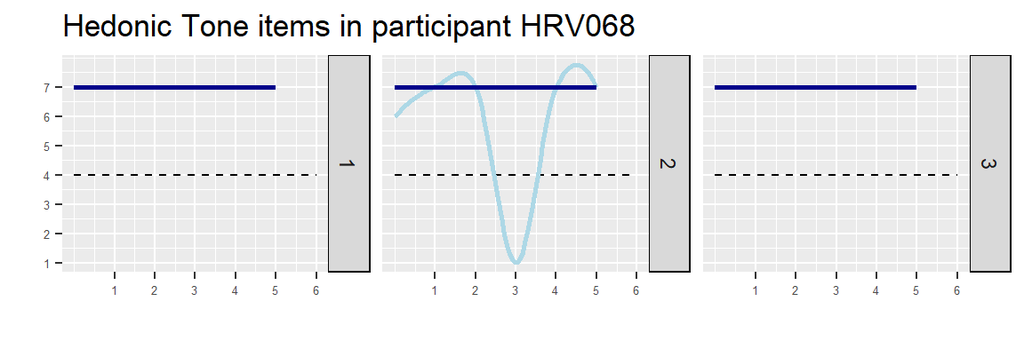

```r
plot.traj(ema,var="HT","HRV068") # checking items v1-v3 HRV068
```

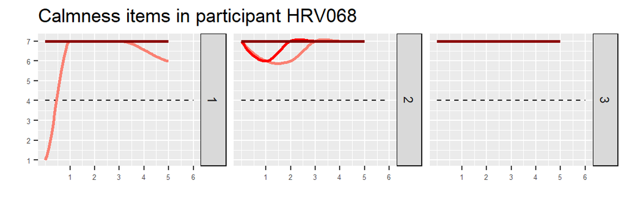

```r
plot.traj(ema,var="CA","HRV068") # checking item t3 HRV068
```

**b) Independence model**

Second, we specify an **independence model on level 2**, by specifying only variances but not covariances on this level. If this model holds, it will mean that “*there is cluster-level structure, but not substantively interesting structural model*”, and we can focus our analyses on the pooled within-cluster matrix. Otherwise, it will mean that some kind of structure exists on Level 2.

```r
# one-factor within model + independence between model
m.ind <- cfa('level: 1
                   hedTone_W =~ v1 + v2 + v3
                   Calmness_W =~ t1 + t2 + t3
                   enArousal_W =~ f1 + f2 + f3
                   level: 2
                   v1 ~~ v1
                   v2 ~~ v2
                   v3 ~~ v3
                   t1 ~~ t1
                   t2 ~~ t2
                   t3 ~~ t3
                   f1 ~~ f1
                   f2 ~~ f2
                   f3 ~~ f3',data=Mood,cluster='ID',std.lv=TRUE)
```

**c) Saturated model**

Third, we specify a **saturated model for the between-clusters part** that fits a full covariance matrix to the family-level observations. This allows us “to examine the best possible fit given the individual-level [here, within-individual] model” (Hox, 2010). If this model holds, the factors at the within-level in this model correspond to *‘within-only’ constructs*, meaning that the construct only ‘exists’ at the within level, whereas lv2 variation is just ‘spurious’ (Stapelton et al., 2016). The saturated model converges with no Heywood cases.

```r
# one-factor within model + saturated between part
m.sat <- cfa('level: 1
                   hedTone_W =~ v1 + v2 + v3
                   Calmness_W =~ t1 + t2 + t3
                   enArousal_W =~ f1 + f2 + f3
                   level: 2
                   v1 ~~ v1 + v2 + v3 + t1 + t2 + t3 + f1 + f2 + f3
                   v2 ~~ v2 + v3 + t1 + t2 + t3 + f1 + f2 + f3
                   v3 ~~ v3 + t1 + t2 + t3 + f1 + f2 + f3
                   t1 ~~ t1 + t2 + t3 + f1 + f2 + f3
                   t2 ~~ t2 + t3 + f1 + f2 + f3
                   t3 ~~ t3 + f1 + f2 + f3
                   f1 ~~ f1 + f2 + f3
                   f2 ~~ f2 + f3
                   f3 ~~ f3', data=Mood,cluster='ID',std.lv=TRUE)
```

Finally, we evaluate the fit of these benchmark models. If the structure on level 2 holds, all models (and especially the Null and the Independence model) should be rejected. Accordingly, we can note that both the null and the independence models are rejected, whereas roughly acceptable fit is shown by the **saturated model**. Consequently, the saturated model will be considered for evaluating the fit of the hypothesized models.

```r
fit.ind(model=c(m.null,m.ind,m.sat),models.names=c("Lv2 Null","Lv2 Independence","Lv2 Saturated"))
```

|  | npar | chisq | df | rmsea | cfi | srmr_within | srmr_between | AICw | BICw |
| --- | --- | --- | --- | --- | --- | --- | --- | --- | --- |
| Lv2 Saturated | 75 | 191.588 | 24 | 0.066 | 0.975 | 0.037 | 0.004 | 1 | 1 |
| Lv2 Independence | 39 | 1161.917 | 60 | 0.107 | 0.833 | 0.064 | 0.626 | 0 | 0 |
| Lv2 Null | 30 | 2462.376 | 69 | 0.147 | 0.638 | 0.117 | NA | 0 | 0 |

#### 2.1.2.2. Multilevel models

Here, we specify the **hypothesized MCFA models** and a set of alternative models with a different number of dimensions. Note that each model is parametrized by standardizing the latent factors with `std.lv = TRUE` to avoid fixing to 1 the first indicator of each dimension since the interest is on factor loadings. Following Jag & Jorgensen (2017), we also evaluate **cross-level isomorphism** by specifying more restrictive models with weak and strong invariance across levels, respectively.

##### a) Configural invariance

Here, we specify the configural-invariance model `m3x3`, assuming **3 latent variables on both levels**. We can note that the model shows an improper solution (**Heywood case**), which will be handled in the following section 2.1.2.3.

```r
# hypothesized multilevel model (negative variance -> see HEYWOOD CASES)
m3x3 <- cfa('level: 1
             hedTone_w =~ v1 + v2 + v3
             Calmness_w =~ t1 + t2 + t3
             enArousal_w =~ f1 + f2 + f3
             level: 2
             hedTone_b =~ v1 + v2 + v3
             Calmness_b =~ t1 + t2 + t3
             enArousal_b =~ f1 + f2 + f3',
            data=Mood,cluster='ID',std.lv=TRUE)
```

##### b) Alternative models

Here, alternative models are specified with less latent factors on level 1 and/or level 2. Specifically, models with two latent variables (Positive Tone and Energetic Arousal) are justified by the strong correlation between Hedonic Tone and Calmness items, especially on level 2 (see also Wilhelm & Schoebi, 2007; Menghini et al., 2022). We can note that models `m2x3` and `m2x2` show improper solutions (**Heywood cases**), which will be handled in the following section 2.1.2.3.

```r
# 3 latent on lv1, 2 latent on lv2
m3x2 <- cfa('level: 1
             hedTone_w =~ v1 + v2 + v3
             Calmness_w =~ t1 + t2 + t3
             enArousal_w =~ f1 + f2 + f3
             level: 2
             PosTone_b =~ v1 + v2 + v3 + t1 + t2 + t3
             enArousal_b =~ f1 + f2 + f3',
            data=Mood,cluster='ID',std.lv=TRUE)
# 2 latent on lv1, 3 latent on lv2
m2x3 <- cfa('level: 1
             PosTone_w =~ v1 + v2 + v3 + t1 + t2 + t3
             enArousal_w =~ f1 + f2 + f3
             level: 2
             hedTone_b =~ v1 + v2 + v3
             Calmness_b =~ t1 + t2 + t3
             enArousal_b =~ f1 + f2 + f3',
            data=Mood,cluster='ID',std.lv=TRUE)
# 2 latent factors on both levels
m2x2 <- cfa('level: 1
             PosTone_w =~ v1 + v2 + v3 + t1 + t2 + t3
             enArousal_w =~ f1 + f2 + f3
             level: 2
             PosTone_b =~ v1 + v2 + v3 + t1 + t2 + t3
             enArousal_b =~ f1 + f2 + f3',
            data=Mood,cluster='ID',std.lv=TRUE)
```

##### c) Cross-level invariance

Finally, we follow Jag & Jorgensen (2017) by evaluating different levels of factor invariance: (1) **configural invariance**, where the same factor structure holds but factor loadings differ across levels as in model `m3x3`, (2) **weak factorial invariance**, where the factor loadings are equal across levels, and (3) **strong factorial invariance**, when the values of factor loadings and intercepts are equal across levels, and the residual variance on level 2 is zero. Here we specify the models assuming, respectively, weak and strong invariance across levels. We can note that the former model shows an improper solution (**Heywood case**), which will be handled in the following section 2.1.2.3.

```r
# weak invariance model (negative variance -> see HEYWOOD CASES)
m3x3.weakInv <- cfa('level: 1
                 hedTone_w =~ a*v1 + b*v2 + c*v3
                 Calmness_w =~ d*t1 + e*t2 + f*t3
                 enArousal_w =~ g*f1 + h*f2 + i*f3
                 level: 2
                 hedTone_b =~ a*v1 + b*v2 + c*v3
                 Calmness_b =~ d*t1 + e*t2 + f*t3
                 enArousal_b =~ g*f1 + h*f2 + i*f3',
                data=Mood,cluster='ID',std.lv=TRUE)
# strong invariance
m3x3.strInv <- cfa('level: 1
                    hedTone_w =~ a*v1 + b*v2 + c*v3
                    Calmness_w =~ d*t1 + e*t2 + f*t3
                    enArousal_w =~ g*f1 + h*f2 + i*f3
                    level: 2
                    hedTone_b =~ a*v1 + b*v2 + c*v3
                    Calmness_b =~ d*t1 + e*t2 + f*t3
                    enArousal_b =~ g*f1 + h*f2 + i*f3
                    v1 ~~ 0*v1
                    v2 ~~ 0*v2
                    v3 ~~ 0*v3
                    t1 ~~ 0*t1
                    t2 ~~ 0*t2
                    t3 ~~ 0*t3
                    f1 ~~ 0*f1
                    f2 ~~ 0*f2
                    f3 ~~ 0*f3',
                   data=Mood,cluster='ID',std.lv=TRUE)
```

#### 2.1.2.3. Heywood cases

```r
# m3x3
parameterestimates(m3x3)[parameterestimates(m3x3)$op=="~~" & parameterestimates(m3x3)$est<0,
                         c("lhs","level","est","se","ci.lower","ci.upper")]
```

|  | lhs | level | est | se | ci.lower | ci.upper |
| --- | --- | --- | --- | --- | --- | --- |
| 50 | t2 | 2 | -0.00648248 | 0.009009711 | -0.02414119 | 0.01117623 |

```r
# m2x3
parameterestimates(m2x3)[parameterestimates(m2x3)$op=="~~" & parameterestimates(m2x3)$est<0,
                         c("lhs","level","est","se","ci.lower","ci.upper")]
```

|  | lhs | level | est | se | ci.lower | ci.upper |
| --- | --- | --- | --- | --- | --- | --- |
| 46 | t2 | 2 | -0.01706527 | 0.009003983 | -0.03471275 | 0.0005822132 |

```r
# m2x2
parameterestimates(m2x2)[parameterestimates(m2x2)$op=="~~" & parameterestimates(m2x2)$est<0,
                         c("lhs","level","est","se","ci.lower","ci.upper")]
```

|  | lhs | level | est | se | ci.lower | ci.upper |
| --- | --- | --- | --- | --- | --- | --- |
| 47 | t3 | 2 | -0.0006066165 | 0.008778495 | -0.01781215 | 0.01659892 |

```r
# m3x3.weakInv
parameterestimates(m3x3.weakInv)[parameterestimates(m3x3.weakInv)$op=="~~" & parameterestimates(m3x3.weakInv)$est<0,
                                 c("lhs","level","est","se","ci.lower","ci.upper")]
```

|  | lhs | level | est | se | ci.lower | ci.upper |
| --- | --- | --- | --- | --- | --- | --- |
| 50 | t2 | 2 | -0.004588691 | 0.009043012 | -0.02231267 | 0.01313529 |

##### a) Fixating variance

As a first strategy to solve the improper solutions, we refit the models by **fixating the residual variance** of problematic items to the 15% of the variance estimated for these items at level 2. In other words, we make the assumption that these items have a reliability around 85% (see Joreskog & Sobrom, 1996). We can see that the residual variance of both `t2` and `t3` should be fixated to solve the problem for models `m3x3` and `m2x3`, and `m3x3.weakInv`, whereas fixating item `t3` was enough to solve the problem for model `m2x2`.

```r
# m3x3: fixating residual variance of item t2 ........................................................
m3x3.fix <- 'level: 1
             hedTone_w =~ v1 + v2 + v3
             Calmness_w =~ t1 + t2 + t3
             enArousal_w =~ f1 + f2 + f3
             level: 2
             hedTone_b =~ v1 + v2 + v3
             Calmness_b =~ t1 + t2 + t3
             enArousal_b =~ f1 + f2 + f3
             t2 ~~ rho2 * t2'
fit <- lmer(t2 ~  1 + (1|ID), data=Mood) # null LMER model
t2varlv2 <- as.data.frame(VarCorr(fit))[1,4] # between-subjects variance of item t2
m3x3.fix <- cfa(gsub("rho2",t2varlv2*.15,m3x3.fix),data=Mood,cluster='ID',std.lv=TRUE) # fixating rho2
# same problem with item t3
parameterestimates(m3x3.fix)[parameterestimates(m3x3.fix)$op=="~~" & parameterestimates(m3x3.fix)$est<0,
                             c("lhs","level","est","se","ci.lower","ci.upper")]
```

|  | lhs | level | est | se | ci.lower | ci.upper |
| --- | --- | --- | --- | --- | --- | --- |
| 51 | t3 | 2 | -0.02416616 | 0.01518654 | -0.05393123 | 0.005598909 |

```r
# m3x3: fixating also residual variance of item t3
m3x3.fix2 <- 'level: 1
             hedTone_w =~ v1 + v2 + v3
             Calmness_w =~ t1 + t2 + t3
             enArousal_w =~ f1 + f2 + f3
             level: 2
             hedTone_b =~ v1 + v2 + v3
             Calmness_b =~ t1 + t2 + t3
             enArousal_b =~ f1 + f2 + f3
             t2 ~~ rho2 * t2
             t3 ~~ rho2b * t3'
fit <- lmer(t3 ~  1 + (1|ID), data=Mood) # null LMER model
t3varlv2 <- as.data.frame(VarCorr(fit))[1,4] # between-subjects variance of item t2
m3x3.fix2 <- cfa(gsub("rho2",t2varlv2*.15,
                     gsub("rho2b",t3varlv2*.15,m3x3.fix2)),data=Mood,cluster='ID',std.lv=TRUE) # fixating rho2b
# m2x3: fixating residual variance of item t2 ........................................................
m2x3.fix <- 'level: 1
             PosTone_w =~ v1 + v2 + v3 + t1 + t2 + t3
             enArousal_w =~ f1 + f2 + f3
             level: 2
             hedTone_b =~ v1 + v2 + v3
             Calmness_b =~ t1 + t2 + t3
             enArousal_b =~ f1 + f2 + f3
             t2 ~~ rho2 * t2'
m2x3.fix <- cfa(gsub("rho2",t2varlv2*.15,m2x3.fix),data=Mood,cluster='ID',std.lv=TRUE) # fixating rho2b
# same problem with item t3
parameterestimates(m2x3.fix)[parameterestimates(m2x3.fix)$op=="~~" & parameterestimates(m2x3.fix)$est<0,
                             c("lhs","level","est","se","ci.lower","ci.upper")]
```

|  | lhs | level | est | se | ci.lower | ci.upper |
| --- | --- | --- | --- | --- | --- | --- |
| 47 | t3 | 2 | -0.03374337 | 0.0161018 | -0.06530232 | -0.002184422 |

```r
# m2x3: fixating also residual variance of item t3
m2x3.fix2 <- 'level: 1
             PosTone_w =~ v1 + v2 + v3 + t1 + t2 + t3
             enArousal_w =~ f1 + f2 + f3
             level: 2
             hedTone_b =~ v1 + v2 + v3
             Calmness_b =~ t1 + t2 + t3
             enArousal_b =~ f1 + f2 + f3
             t2 ~~ rho2 * t2
             t3 ~~ rho2b * t3'
m2x3.fix2 <- cfa(gsub("rho2",t2varlv2*.15,
                     gsub("rho2b",t3varlv2*.15,m2x3.fix2)),data=Mood,cluster='ID',std.lv=TRUE) # fixating rho2b
# m2x2: fixating residual variance of item t3 ........................................................
m2x2.fix <- 'level: 1
             PosTone_w =~ v1 + v2 + v3 + t1 + t2 + t3
             enArousal_w =~ f1 + f2 + f3
             level: 2
             PosTone_b =~ v1 + v2 + v3 + t1 + t2 + t3
             enArousal_b =~ f1 + f2 + f3
             t3 ~~ rho2 * t3'
m2x2.fix <- cfa(gsub("rho2",t3varlv2*.15,m2x2.fix),data=Mood,cluster='ID',std.lv=TRUE) # fixating rho2
# m3x3.weakInv: fixating residual variance of item t2 ........................................................
m3x3.weakInv.fix <- 'level: 1
                     hedTone_w =~ a*v1 + b*v2 + c*v3
                     Calmness_w =~ d*t1 + e*t2 + f*t3
                     enArousal_w =~ g*f1 + h*f2 + i*f3
                     level: 2
                     hedTone_b =~ a*v1 + b*v2 + c*v3
                     Calmness_b =~ d*t1 + e*t2 + f*t3
                     enArousal_b =~ g*f1 + h*f2 + i*f3
                     t2 ~~ rho2 * t2'
m3x3.weakInv.fix <- cfa(gsub("rho2",t2varlv2*.15,m3x3.weakInv.fix),data=Mood,cluster='ID',std.lv=TRUE) # fixating rho2
# same problem with item t3
parameterestimates(m3x3.weakInv.fix)[parameterestimates(m3x3.weakInv.fix)$op=="~~" & parameterestimates(m3x3.weakInv.fix)$est<0,
                                     c("lhs","level","est","se","ci.lower","ci.upper")]
```

|  | lhs | level | est | se | ci.lower | ci.upper |
| --- | --- | --- | --- | --- | --- | --- |
| 51 | t3 | 2 | -0.02279103 | 0.01331747 | -0.04889279 | 0.003310742 |

```r
# m3x3.weakInv: fixating also residual variance of item t3
m3x3.weakInv.fix2 <- 'level: 1
                     hedTone_w =~ a*v1 + b*v2 + c*v3
                     Calmness_w =~ d*t1 + e*t2 + f*t3
                     enArousal_w =~ g*f1 + h*f2 + i*f3
                     level: 2
                     hedTone_b =~ a*v1 + b*v2 + c*v3
                     Calmness_b =~ d*t1 + e*t2 + f*t3
                     enArousal_b =~ g*f1 + h*f2 + i*f3
                     t2 ~~ rho2 * t2
                     t3 ~~ rho2b * t3'
m3x3.weakInv.fix2 <- cfa(gsub("rho2",t2varlv2*.15,
                             gsub("rho2b",t3varlv2*.15,m3x3.weakInv.fix2)),data=Mood,cluster='ID',std.lv=TRUE) # fixating rho2
```

##### b) Sampling fluctuations

As a second alternative strategy, we check if the **removal of some participants** can solve the improper solutions. Indeed, Heywood cases are likely due to population variances that are close to zero (but positive), such that that the negative estimates are just the result of **random sampling fluctuations** (Van Driel, 1978; Kolenikov & Bollen, 2012).

Specifically, due to our main focus on cross-level isomorphism, we only conduct the following analysis on models `m3x3` and `m3x3.weakInv`. Here, we re-specify both models by excluding each participant one-by-one (i.e., **influential analysis**). Then, we repeat the procedure by removing the participants whose exclusion is associated with the highest estimated variance, until the variance becomes positive in both models.

**show influential analysis**

First, the parameters are estimated and plotted after the exclusion of each participant. For both models, we can note that `t2` variance remains negative in any case. The exclusion of participant `HRV036` seems to lead to the highest increase in `t2` variance considering both models.

```r
# m3x3
write.csv(influential.analysis(data=Mood,
                               parameter="var"),"heywood cases/negVar.m3x3.0.csv",row.names=FALSE)
# m3x3.weakInv
write.csv(influential.analysis(data=Mood,
                               m='level: 1
                                  hedTone_w =~ a*v1 + b*v2 + c*v3
                                  Calmness_w =~ d*t1 + e*t2 + f*t3
                                  enArousal_w =~ g*f1 + h*f2 + i*f3
                                  level: 2
                                  hedTone_b =~ a*v1 + b*v2 + c*v3
                                  Calmness_b =~ d*t1 + e*t2 + f*t3
                                  enArousal_b =~ g*f1 + h*f2 + i*f3',
                               parameter="var"),"heywood cases/negVar.m3x3.weakInv.0.csv",row.names=FALSE)
```

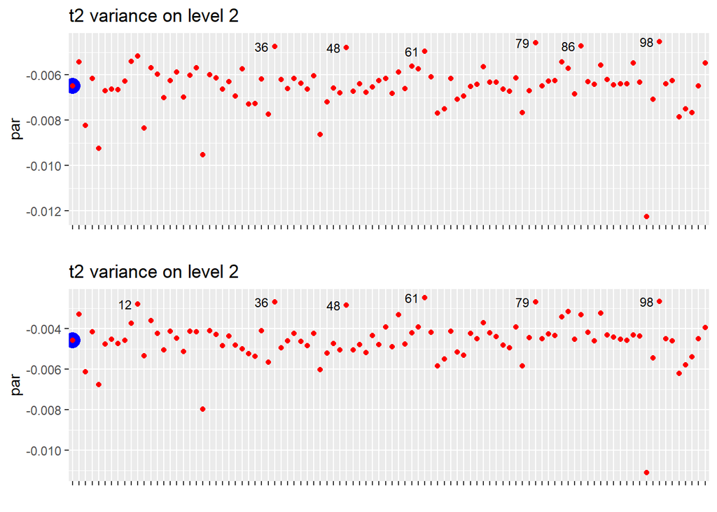

```r
# t2 variance in m3x3 (above) and m3x3.weakInv (below)
grid.arrange(plot.influential(data=read.csv("heywood cases/negVar.m3x3.0.csv"),par="var",variable="t2",level=2,
                              threshold_upper=-.005),
             plot.influential(data=read.csv("heywood cases/negVar.m3x3.weakInv.0.csv"),par="var",variable="t2",level=2,
                              threshold_upper=-.003))
```

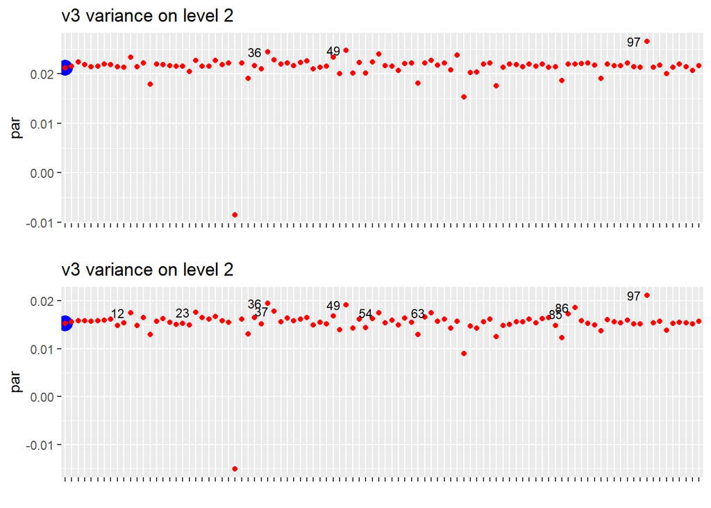

```r
# v3 variance in m3x3 (above) and m3x3.weakInv (below)
grid.arrange(plot.influential(data=read.csv("heywood cases/negVar.m3x3.0.csv"),par="var",variable="v3",level=2,
                              threshold_upper = .024),
             plot.influential(data=read.csv("heywood cases/negVar.m3x3.weakInv.0.csv"),par="var",variable="v3",level=2,
                              threshold_upper =.017))
```

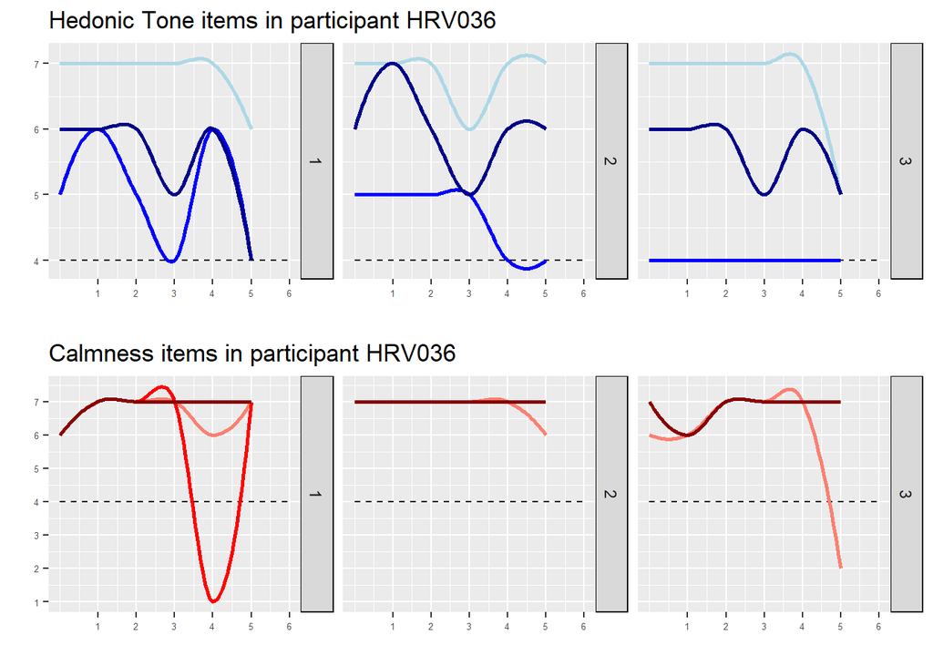

```r
# participant HRV036
grid.arrange(plot.traj(ema,var="HT","HRV036"),plot.traj(ema,var="CA","HRV036"),nrow=2)
```

Second, we replicate the procedure by also excluding participant `HRV036`. For both models, we can note that `t2` variance remains negative in any case. The exclusion of participant `HRV098` seems to lead to the highest increase in `t2` variance considering both models.

```r
# m3x3
write.csv(influential.analysis(data=Mood[Mood$ID!="HRV036",],
                               parameter="var"),"heywood cases/negVar.m3x3.1.csv",row.names=FALSE)
# m3x3.weakInv
write.csv(influential.analysis(data=Mood[Mood$ID!="HRV036",],
                               m='level: 1
                                  hedTone_w =~ a*v1 + b*v2 + c*v3
                                  Calmness_w =~ d*t1 + e*t2 + f*t3
                                  enArousal_w =~ g*f1 + h*f2 + i*f3
                                  level: 2
                                  hedTone_b =~ a*v1 + b*v2 + c*v3
                                  Calmness_b =~ d*t1 + e*t2 + f*t3
                                  enArousal_b =~ g*f1 + h*f2 + i*f3',
                               parameter="var"),"heywood cases/negVar.m3x3.weakInv.1.csv",row.names=FALSE)
```

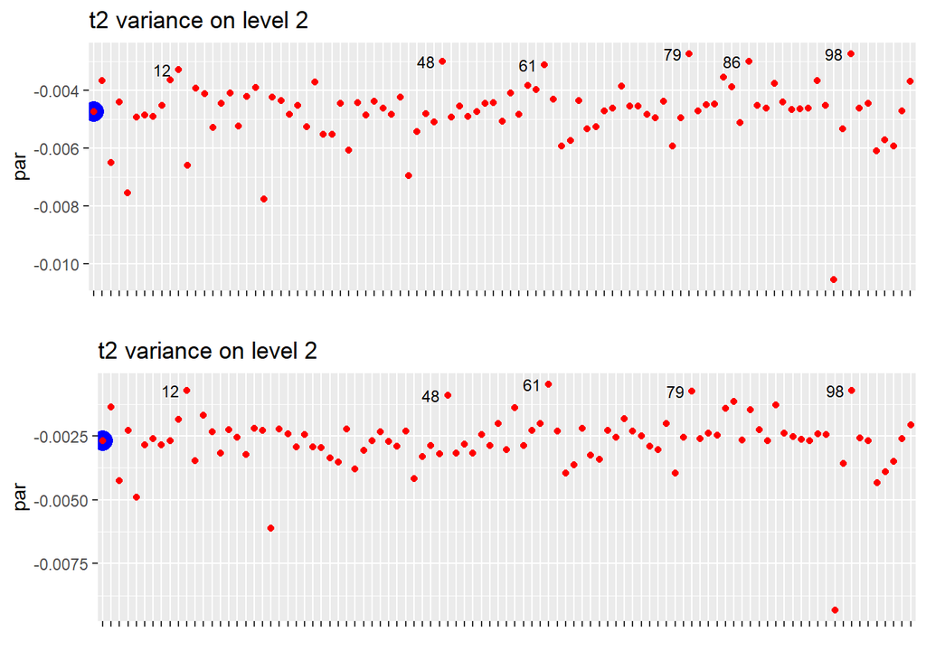

```r
# t2 variance in m3x3 (above) and m3x3.weakInv (below)
grid.arrange(plot.influential(data=read.csv("heywood cases/negVar.m3x3.1.csv"),par="var",variable="t2",level=2,
                              threshold_upper=-.0035),
             plot.influential(data=read.csv("heywood cases/negVar.m3x3.weakInv.1.csv"),par="var",variable="t2",level=2,
                              threshold_upper=-.001))
```

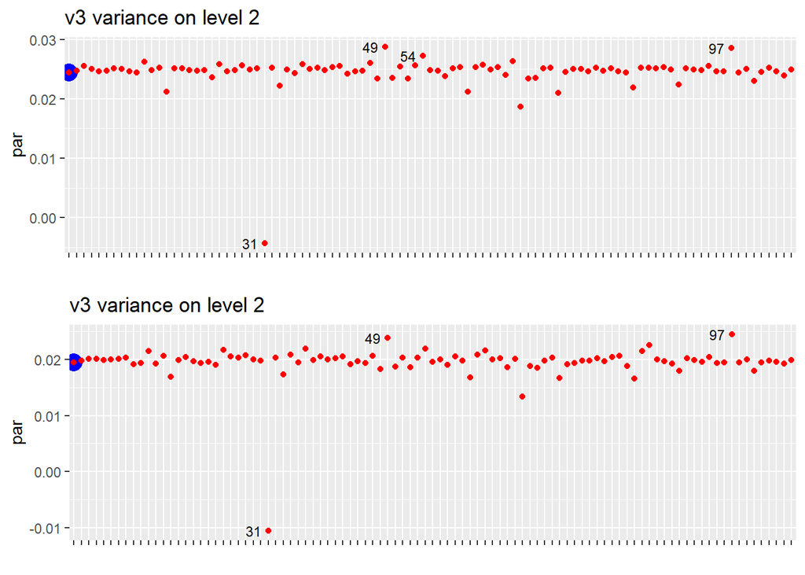

```r
# v3 variance in m3x3 (above) and m3x3.weakInv (below)
grid.arrange(plot.influential(data=read.csv("heywood cases/negVar.m3x3.1.csv"),par="var",variable="v3",level=2,
                              threshold_upper = .027,threshold_lower = 0),
             plot.influential(data=read.csv("heywood cases/negVar.m3x3.weakInv.1.csv"),par="var",variable="v3",level=2,
                              threshold_upper =.023,threshold_lower = 0))
```

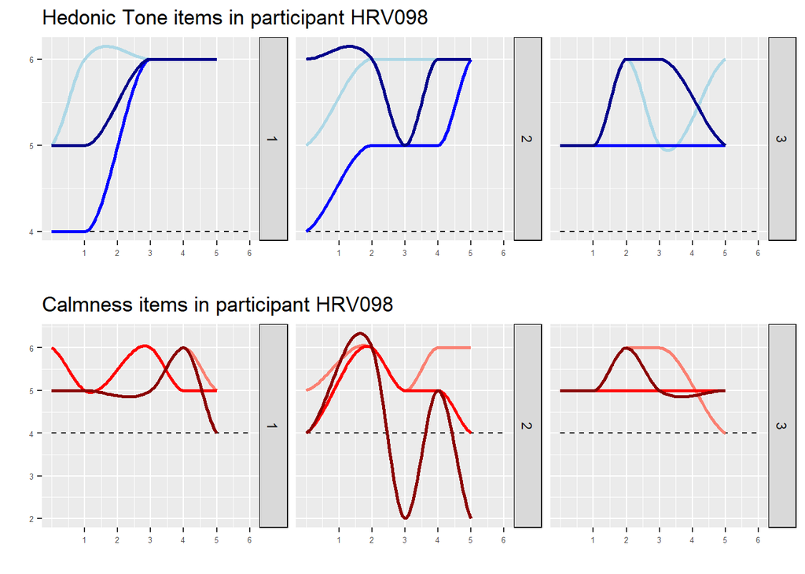

```r
# participant HRV098
grid.arrange(plot.traj(ema,var="HT","HRV098"),plot.traj(ema,var="CA","HRV098"),nrow=2)
```

Third, we replicate the procedure by also excluding participant `HRV098`. We can note that `t2` variance remains negative in any case for model `m3x3`, whereas the exclusion of a number of participants solves the problem for model `m3x3.weakInv`. The exclusion of participant `HRV061` seems to lead to the highest increase in `t2` variance in both models.

```r
# m3x3
write.csv(influential.analysis(data=Mood[!Mood$ID%in%c("HRV036","HRV098"),],
                               parameter="var"),"heywood cases/negVar.m3x3.2.csv",row.names=FALSE)
# m3x3.weakInv
write.csv(influential.analysis(data=Mood[!Mood$ID%in%c("HRV036","HRV098"),],
                               m='level: 1
                                  hedTone_w =~ a*v1 + b*v2 + c*v3
                                  Calmness_w =~ d*t1 + e*t2 + f*t3
                                  enArousal_w =~ g*f1 + h*f2 + i*f3
                                  level: 2
                                  hedTone_b =~ a*v1 + b*v2 + c*v3
                                  Calmness_b =~ d*t1 + e*t2 + f*t3
                                  enArousal_b =~ g*f1 + h*f2 + i*f3',
                               parameter="var"),"heywood cases/negVar.m3x3.weakInv.2.csv",row.names=FALSE)
```

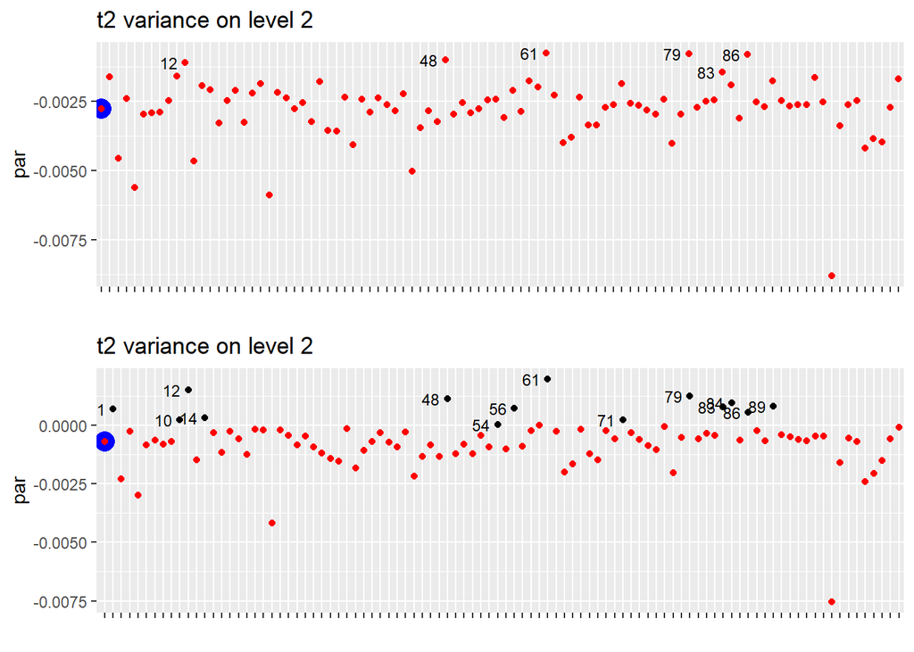

```r
# t2 variance in m3x3 (above) and m3x3.weakInv (below)
grid.arrange(plot.influential(data=read.csv("heywood cases/negVar.m3x3.2.csv"),par="var",variable="t2",level=2,
                              threshold_upper=-.0015),
             plot.influential(data=read.csv("heywood cases/negVar.m3x3.weakInv.2.csv"),par="var",variable="t2",level=2,
                              threshold_upper=0))
```

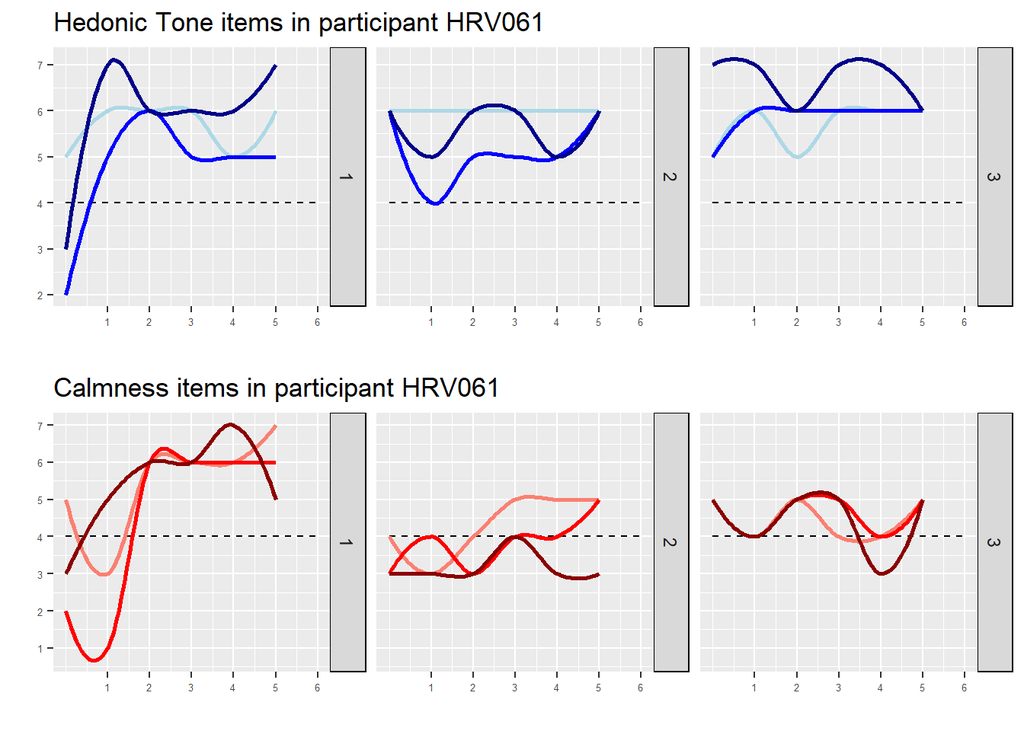

```r
# participant HRV061
grid.arrange(plot.traj(ema,var="HT","HRV061"),plot.traj(ema,var="CA","HRV061"),nrow=2)
```

```r
# m3x3
write.csv(influential.analysis(data=Mood[!Mood$ID%in%c("HRV036","HRV098","HRV061"),],
                               parameter="var"),"heywood cases/negVar.m3x3.3.csv",row.names=FALSE)
# m3x3.weakInv
write.csv(influential.analysis(data=Mood[!Mood$ID%in%c("HRV036","HRV098","HRV061"),],
                               m='level: 1
                                  hedTone_w =~ a*v1 + b*v2 + c*v3
                                  Calmness_w =~ d*t1 + e*t2 + f*t3
                                  enArousal_w =~ g*f1 + h*f2 + i*f3
                                  level: 2
                                  hedTone_b =~ a*v1 + b*v2 + c*v3
                                  Calmness_b =~ d*t1 + e*t2 + f*t3
                                  enArousal_b =~ g*f1 + h*f2 + i*f3',
                               parameter="var"),"heywood cases/negVar.m3x3.weakInv.3.csv",row.names=FALSE)
```

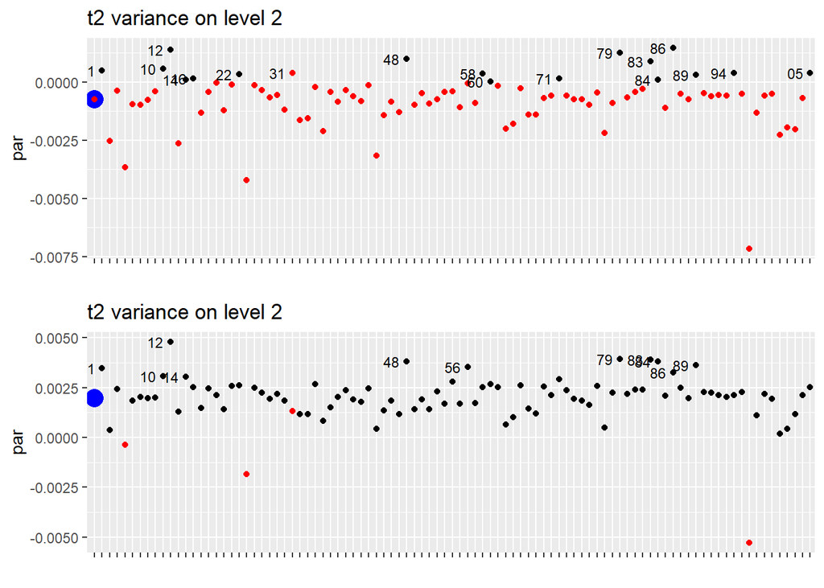

```r
# t2 variance in m3x3 (above) and m3x3.weakInv (below)
grid.arrange(plot.influential(data=read.csv("heywood cases/negVar.m3x3.3.csv"),par="var",variable="t2",level=2,
                              threshold_upper=0),
             plot.influential(data=read.csv("heywood cases/negVar.m3x3.weakInv.3.csv"),par="var",variable="t2",level=2,
                              threshold_upper=.003))
```

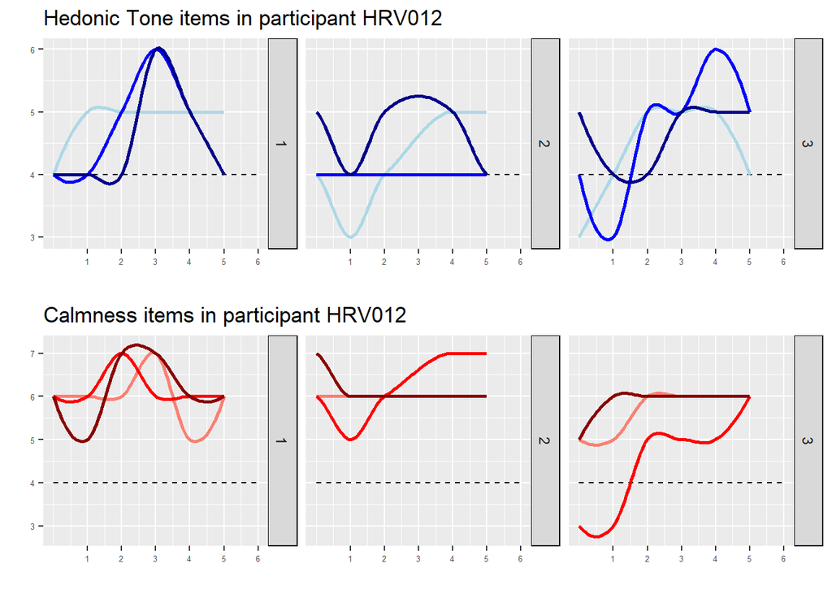

```r
# participant HRV012
grid.arrange(plot.traj(ema,var="HT","HRV012"),plot.traj(ema,var="CA","HRV012"),nrow=2)
```

##### Summary of results

After the **removal of 4 participants (4.12%)**, the estimated variance for item `t2` is positive in both models `m3x3` and `m3x3.weakInv`. Both models specified without participants `HRV036`, `HRV061`, `HRV098` and `HRV012` do not show any other Heywood case. However, Heywood cases are still present in all the alternative models.

```r
# excluding 4 participants associated with Heywood cases in models m3x3 and m3x3.weak
Mood_noInfl4 <- Mood[!Mood$ID%in%c("HRV036","HRV061","HRV098","HRV012"),]

# refitting m3x3
m3x3_noInfl4 <- cfa('level: 1
             hedTone_w =~ v1 + v2 + v3
             Calmness_w =~ t1 + t2 + t3
             enArousal_w =~ f1 + f2 + f3
             level: 2
             hedTone_b =~ v1 + v2 + v3
             Calmness_b =~ t1 + t2 + t3
             enArousal_b =~ f1 + f2 + f3',
            data=Mood_noInfl4,cluster='ID',std.lv=TRUE)
# refitting m3x3.weakInv
m3x3.weakInv_noInfl4 <- cfa('level: 1
                 hedTone_w =~ a*v1 + b*v2 + c*v3
                 Calmness_w =~ d*t1 + e*t2 + f*t3
                 enArousal_w =~ g*f1 + h*f2 + i*f3
                 level: 2
                 hedTone_b =~ a*v1 + b*v2 + c*v3
                 Calmness_b =~ d*t1 + e*t2 + f*t3
                 enArousal_b =~ g*f1 + h*f2 + i*f3',
                data=Mood_noInfl4,cluster='ID',std.lv=TRUE)
# refitting m3x2
m3x2_noInfl4 <- cfa('level: 1
             hedTone_w =~ v1 + v2 + v3
             Calmness_w =~ t1 + t2 + t3
             enArousal_w =~ f1 + f2 + f3
             level: 2
             PosTone_b =~ v1 + v2 + v3 + t1 + t2 + t3
             enArousal_b =~ f1 + f2 + f3',
            data=Mood_noInfl4,cluster='ID',std.lv=TRUE)
# refitting m2x3
m2x3_noInfl4 <- cfa('level: 1
             PosTone_w =~ v1 + v2 + v3 + t1 + t2 + t3
             enArousal_w =~ f1 + f2 + f3
             level: 2
             hedTone_b =~ v1 + v2 + v3
             Calmness_b =~ t1 + t2 + t3
             enArousal_b =~ f1 + f2 + f3',
            data=Mood_noInfl4,cluster='ID',std.lv=TRUE)
# refitting m2x2
m2x2_noInfl4 <- cfa('level: 1
             PosTone_w =~ v1 + v2 + v3 + t1 + t2 + t3
             enArousal_w =~ f1 + f2 + f3
             level: 2
             PosTone_b =~ v1 + v2 + v3 + t1 + t2 + t3
             enArousal_b =~ f1 + f2 + f3',
            data=Mood_noInfl4,cluster='ID',std.lv=TRUE)
# strong invariance
m3x3.strInv_noInfl4 <- cfa('level: 1
                    hedTone_w =~ a*v1 + b*v2 + c*v3
                    Calmness_w =~ d*t1 + e*t2 + f*t3
                    enArousal_w =~ g*f1 + h*f2 + i*f3
                    level: 2
                    hedTone_b =~ a*v1 + b*v2 + c*v3
                    Calmness_b =~ d*t1 + e*t2 + f*t3
                    enArousal_b =~ g*f1 + h*f2 + i*f3
                    v1 ~~ 0*v1
                    v2 ~~ 0*v2
                    v3 ~~ 0*v3
                    t1 ~~ 0*t1
                    t2 ~~ 0*t2
                    t3 ~~ 0*t3
                    f1 ~~ 0*f1
                    f2 ~~ 0*f2
                    f3 ~~ 0*f3',
                   data=Mood_noInfl4,cluster='ID',std.lv=TRUE)
# refitting one-factor within model + saturated between part
m.sat_noInfl4 <- cfa('level: 1
                   hedTone_W =~ v1 + v2 + v3
                   Calmness_W =~ t1 + t2 + t3
                   enArousal_W =~ f1 + f2 + f3
                   level: 2
                   v1 ~~ v1 + v2 + v3 + t1 + t2 + t3 + f1 + f2 + f3
                   v2 ~~ v2 + v3 + t1 + t2 + t3 + f1 + f2 + f3
                   v3 ~~ v3 + t1 + t2 + t3 + f1 + f2 + f3
                   t1 ~~ t1 + t2 + t3 + f1 + f2 + f3
                   t2 ~~ t2 + t3 + f1 + f2 + f3
                   t3 ~~ t3 + f1 + f2 + f3
                   f1 ~~ f1 + f2 + f3
                   f2 ~~ f2 + f3
                   f3 ~~ f3', data=Mood_noInfl4,cluster='ID',std.lv=TRUE)
```

#### 2.1.2.4. Model comparison

Here, we compare the multilevel models specified above by considering both the **fit indices and information criteria**. Three model comparisons are performed on different subsets of the sample, in order to account for strategies used to handle the **Heywood cases** highlighted above. Across all model comparisons, we can note that both the configural model `m3x3` and the weak-invariance models `m3x3.weakInv` show acceptable fit indices, with a **better fit than the saturated** model (except for `srmr_between`), whereas all the **alternative models are rejected**, including the strong-invariance model `m3x3.strInv`. Across all model comparisons, the **weak invariance model shows the best fit** in terms of `rmsea` and the strongest evidence in terms of `BICw`. Thus, model `m3x3.weakInv` is selected as the best model.

```r
# all participants (N = 97), with lv-2 Heywood cases in m3x3, m3x3.weakInv, m2x3, and m2x2
fit.ind(model=c(m.sat,m3x3,m3x2,m2x2,m2x3,m3x3.weakInv,m3x3.strInv),
        models.names=c("m.sat","m3x3","m3x2","m2x2","m2x3","m3x3.weakInv","m3x3.strInv"))
```

|  | npar | chisq | df | rmsea | cfi | srmr_within | srmr_between | AICw | BICw |
| --- | --- | --- | --- | --- | --- | --- | --- | --- | --- |
| m3x3.weakInv | 42 | 292.046 | 57 | 0.051 | 0.964 | 0.038 | 0.058 | 0 | 1 |
| m3x3 | 51 | 281.143 | 48 | 0.055 | 0.965 | 0.037 | 0.057 | 0 | 0 |
| m.sat | 75 | 191.588 | 24 | 0.066 | 0.975 | 0.037 | 0.004 | 1 | 0 |
| m3x2 | 49 | 406.222 | 50 | 0.067 | 0.946 | 0.037 | 0.106 | 0 | 0 |
| m3x3.strInv | 33 | 849.526 | 66 | 0.086 | 0.882 | 0.041 | 0.080 | 0 | 0 |
| m2x3 | 49 | 774.056 | 50 | 0.095 | 0.891 | 0.080 | 0.059 | 0 | 0 |
| m2x2 | 47 | 923.639 | 52 | 0.102 | 0.868 | 0.080 | 0.135 | 0 | 0 |

```r
# all participants (N = 97), with lv-2 residual variances of problematic items fixated to the 15% of their total lv-2 variance
fit.ind(model=c(m.sat,m3x3.fix2,m3x2,m2x2.fix,m2x3.fix2,m3x3.weakInv.fix2,m3x3.strInv),
        models.names=c("m.sat","m3x3","m3x2","m2x2","m2x3","m3x3.weakInv","m3x3.strInv"))
```

|  | npar | chisq | df | rmsea | cfi | srmr_within | srmr_between | AICw | BICw |
| --- | --- | --- | --- | --- | --- | --- | --- | --- | --- |
| m3x3.weakInv | 40 | 356.013 | 59 | 0.056 | 0.955 | 0.037 | 0.059 | 0 | 1 |
| m3x3 | 49 | 343.137 | 50 | 0.061 | 0.956 | 0.037 | 0.060 | 0 | 0 |
| m.sat | 75 | 191.588 | 24 | 0.066 | 0.975 | 0.037 | 0.004 | 1 | 0 |
| m3x2 | 49 | 406.222 | 50 | 0.067 | 0.946 | 0.037 | 0.106 | 0 | 0 |
| m3x3.strInv | 33 | 849.526 | 66 | 0.086 | 0.882 | 0.041 | 0.080 | 0 | 0 |
| m2x3 | 47 | 842.193 | 52 | 0.097 | 0.881 | 0.081 | 0.062 | 0 | 0 |
| m2x2 | 46 | 955.414 | 53 | 0.103 | 0.864 | 0.080 | 0.118 | 0 | 0 |

```r
# excluding 4 participants (N = 93), with Heywood cases in m2x3, m2x2, and m3x2 (but not in m3x3 and m3x3.weakInv)
fit.ind(model=c(m.sat_noInfl4,m3x3_noInfl4,m3x2_noInfl4,m2x2_noInfl4,m2x3_noInfl4,m3x3.weakInv_noInfl4,m3x3.strInv_noInfl4),
        models.names=c("m.sat","m3x3","m3x2","m2x2","m2x3","m3x3.weakInv","m3x3.strInv"))
```

|  | npar | chisq | df | rmsea | cfi | srmr_within | srmr_between | AICw | BICw |
| --- | --- | --- | --- | --- | --- | --- | --- | --- | --- |
| m3x3.weakInv | 42 | 294.521 | 57 | 0.052 | 0.964 | 0.038 | 0.056 | 0 | 1 |
| m3x3 | 51 | 281.119 | 48 | 0.056 | 0.964 | 0.037 | 0.055 | 0 | 0 |
| m.sat | 75 | 174.253 | 24 | 0.064 | 0.977 | 0.037 | 0.004 | 1 | 0 |
| m3x2 | 49 | 384.421 | 50 | 0.066 | 0.949 | 0.037 | 0.092 | 0 | 0 |
| m3x3.strInv | 33 | 804.249 | 66 | 0.085 | 0.887 | 0.042 | 0.081 | 0 | 0 |
| m2x3 | 49 | 754.851 | 50 | 0.096 | 0.892 | 0.080 | 0.057 | 0 | 0 |
| m2x2 | 47 | 883.679 | 52 | 0.102 | 0.873 | 0.080 | 0.117 | 0 | 0 |

#### 2.1.2.5. Factor loadings

Here, we inspect the factor loadings from the selected model `m3x3.weakInv` both in the full sample (N = 97) with fixated variances and in the subsample with N = 93 (i.e., excluding the four participants leading to Heywood cases). Both the fully standardized and the unstandardized solutions are shown. From the former, we can see that all items shows significant loadings ranging **from about .60 to about .80 at level 1**, and **from about .85 to about .99 at level 2**, respectively. Correlations between latent variables range from about .21 to about .73 at level 1 and from about .61 to about .79 at level 2, respectively. Similar parameters are estimated from the two subsamples

##### N = 93, STAND

```r
# fully standardized solution (loadings)
standardizedsolution(m3x3.weakInv_noInfl4)[standardizedsolution(m3x3.weakInv_noInfl4)$op=="=~",]
```

|  | lhs | op | rhs | label | est.std | se | z | pvalue | ci.lower | ci.upper |
| --- | --- | --- | --- | --- | --- | --- | --- | --- | --- | --- |
| 1 | hedTone_w | =~ | v1 | a | 0.7444304 | 0.014365025 | 51.82242 | 0 | 0.7162755 | 0.7725853 |
| 2 | hedTone_w | =~ | v2 | b | 0.6196766 | 0.017592975 | 35.22296 | 0 | 0.5851950 | 0.6541582 |
| 3 | hedTone_w | =~ | v3 | c | 0.8093477 | 0.012930589 | 62.59171 | 0 | 0.7840042 | 0.8346912 |
| 4 | Calmness_w | =~ | t1 | d | 0.7122647 | 0.015209846 | 46.82919 | 0 | 0.6824540 | 0.7420755 |
| 5 | Calmness_w | =~ | t2 | e | 0.7785946 | 0.012597817 | 61.80393 | 0 | 0.7539033 | 0.8032858 |
| 6 | Calmness_w | =~ | t3 | f | 0.8053517 | 0.012470604 | 64.58001 | 0 | 0.7809098 | 0.8297936 |
| 7 | enArousal_w | =~ | f1 | g | 0.8316807 | 0.011764138 | 70.69627 | 0 | 0.8086235 | 0.8547380 |
| 8 | enArousal_w | =~ | f2 | h | 0.7752386 | 0.013192923 | 58.76170 | 0 | 0.7493809 | 0.8010962 |
| 9 | enArousal_w | =~ | f3 | i | 0.7870927 | 0.012850189 | 61.25145 | 0 | 0.7619068 | 0.8122786 |
| 37 | hedTone_b | =~ | v1 | a | 0.9303090 | 0.018082480 | 51.44809 | 0 | 0.8948680 | 0.9657500 |

[output cut: 8 more lines]

```r
# fully standardized solution (correlations)
standardizedsolution(m3x3.weakInv_noInfl4)[standardizedsolution(m3x3.weakInv_noInfl4)$op=="~~",][c(13:15,28:30),]
```

|  | lhs | op | rhs | label | est.std | se | z | pvalue | ci.lower | ci.upper |
| --- | --- | --- | --- | --- | --- | --- | --- | --- | --- | --- |
| 22 | hedTone_w | ~~ | Calmness_w |  | 0.7358993 | 0.01970967 | 37.336967 | 0.000000e+00 | 0.6972691 | 0.7745296 |
| 23 | hedTone_w | ~~ | enArousal_w |  | 0.5309251 | 0.02517744 | 21.087338 | 0.000000e+00 | 0.4815782 | 0.5802720 |
| 24 | Calmness_w | ~~ | enArousal_w |  | 0.2114935 | 0.03053140 | 6.927084 | 4.296119e-12 | 0.1516531 | 0.2713340 |
| 58 | hedTone_b | ~~ | Calmness_b |  | 0.7939726 | 0.04237857 | 18.735237 | 0.000000e+00 | 0.7109121 | 0.8770331 |
| 59 | hedTone_b | ~~ | enArousal_b |  | 0.6852941 | 0.05971063 | 11.476920 | 0.000000e+00 | 0.5682634 | 0.8023248 |
| 60 | Calmness_b | ~~ | enArousal_b |  | 0.6094614 | 0.07340010 | 8.303277 | 0.000000e+00 | 0.4655998 | 0.7533230 |

##### N = 93, UNDST

```r
# unstandardized solution (loadings)
parameterestimates(m3x3.weakInv_noInfl4)[parameterestimates(m3x3.weakInv_noInfl4)$op=="=~",]
```

|  | lhs | op | rhs | block | level | label | est | se | z | pvalue | ci.lower | ci.upper |
| --- | --- | --- | --- | --- | --- | --- | --- | --- | --- | --- | --- | --- |
| 1 | hedTone_w | =~ | v1 | 1 | 1 | a | 0.6275995 | 0.01895124 | 33.11653 | 0 | 0.5904557 | 0.6647432 |
| 2 | hedTone_w | =~ | v2 | 1 | 1 | b | 0.5495446 | 0.02098717 | 26.18479 | 0 | 0.5084105 | 0.5906787 |
| 3 | hedTone_w | =~ | v3 | 1 | 1 | c | 0.7043413 | 0.01903200 | 37.00826 | 0 | 0.6670393 | 0.7416433 |
| 4 | Calmness_w | =~ | t1 | 1 | 1 | d | 0.7387544 | 0.02344061 | 31.51601 | 0 | 0.6928116 | 0.7846971 |
| 5 | Calmness_w | =~ | t2 | 1 | 1 | e | 0.7732387 | 0.02050070 | 37.71767 | 0 | 0.7330581 | 0.8134194 |
| 6 | Calmness_w | =~ | t3 | 1 | 1 | f | 0.8144418 | 0.02119781 | 38.42104 | 0 | 0.7728948 | 0.8559887 |
| 7 | enArousal_w | =~ | f1 | 1 | 1 | g | 0.9528411 | 0.02440025 | 39.05047 | 0 | 0.9050175 | 1.0006647 |
| 8 | enArousal_w | =~ | f2 | 1 | 1 | h | 0.8375312 | 0.02354281 | 35.57482 | 0 | 0.7913881 | 0.8836742 |
| 9 | enArousal_w | =~ | f3 | 1 | 1 | i | 0.8060892 | 0.02234378 | 36.07667 | 0 | 0.7622962 | 0.8498822 |
| 37 | hedTone_b | =~ | v1 | 2 | 2 | a | 0.6275995 | 0.01895124 | 33.11653 | 0 | 0.5904557 | 0.6647432 |

[output cut: 8 more lines]

```r
# unstandardized solution (covariances)
parameterestimates(m3x3.weakInv_noInfl4)[parameterestimates(m3x3.weakInv_noInfl4)$op=="~~",][c(13:15,28:30),]
```

|  | lhs | op | rhs | block | level | label | est | se | z | pvalue | ci.lower | ci.upper |
| --- | --- | --- | --- | --- | --- | --- | --- | --- | --- | --- | --- | --- |
| 22 | hedTone_w | ~~ | Calmness_w | 1 | 1 |  | 0.7358993 | 0.01970967 | 37.336967 | 0.000000e+00 | 0.6972691 | 0.7745296 |
| 23 | hedTone_w | ~~ | enArousal_w | 1 | 1 |  | 0.5309251 | 0.02517744 | 21.087338 | 0.000000e+00 | 0.4815782 | 0.5802720 |
| 24 | Calmness_w | ~~ | enArousal_w | 1 | 1 |  | 0.2114935 | 0.03053140 | 6.927084 | 4.296119e-12 | 0.1516531 | 0.2713340 |
| 58 | hedTone_b | ~~ | Calmness_b | 2 | 2 |  | 0.7939726 | 0.04237857 | 18.735237 | 0.000000e+00 | 0.7109121 | 0.8770331 |
| 59 | hedTone_b | ~~ | enArousal_b | 2 | 2 |  | 0.6852941 | 0.05971063 | 11.476920 | 0.000000e+00 | 0.5682634 | 0.8023248 |
| 60 | Calmness_b | ~~ | enArousal_b | 2 | 2 |  | 0.6094614 | 0.07340010 | 8.303277 | 0.000000e+00 | 0.4655998 | 0.7533230 |

##### N = 97, STAND

```r
# fully standardized solution (loadings)
standardizedsolution(m3x3.weakInv.fix2)[standardizedsolution(m3x3.weakInv.fix2)$op=="=~",]
```

|  | lhs | op | rhs | label | est.std | se | z | pvalue | ci.lower | ci.upper |
| --- | --- | --- | --- | --- | --- | --- | --- | --- | --- | --- |
| 1 | hedTone_w | =~ | v1 | a | 0.7404710 | 0.014294419 | 51.80141 | 0 | 0.7124545 | 0.7684876 |
| 2 | hedTone_w | =~ | v2 | b | 0.6165141 | 0.017368755 | 35.49558 | 0 | 0.5824720 | 0.6505562 |
| 3 | hedTone_w | =~ | v3 | c | 0.8098182 | 0.012798342 | 63.27525 | 0 | 0.7847339 | 0.8349025 |
| 4 | Calmness_w | =~ | t1 | d | 0.7132727 | 0.014956925 | 47.68846 | 0 | 0.6839577 | 0.7425877 |
| 5 | Calmness_w | =~ | t2 | e | 0.7640235 | 0.013793806 | 55.38888 | 0 | 0.7369881 | 0.7910588 |
| 6 | Calmness_w | =~ | t3 | f | 0.8028869 | 0.013244948 | 60.61835 | 0 | 0.7769273 | 0.8288466 |
| 7 | enArousal_w | =~ | f1 | g | 0.8210611 | 0.012015801 | 68.33178 | 0 | 0.7975106 | 0.8446116 |
| 8 | enArousal_w | =~ | f2 | h | 0.7679420 | 0.013237014 | 58.01474 | 0 | 0.7419979 | 0.7938860 |
| 9 | enArousal_w | =~ | f3 | i | 0.7835034 | 0.012867860 | 60.88840 | 0 | 0.7582828 | 0.8087239 |
| 37 | hedTone_b | =~ | v1 | a | 0.9193136 | 0.019368571 | 47.46420 | 0 | 0.8813519 | 0.9572753 |

[output cut: 8 more lines]

```r
# fully standardized solution (correlations)
standardizedsolution(m3x3.weakInv.fix2)[standardizedsolution(m3x3.weakInv.fix2)$op=="~~",][c(13:15,28:30),]
```

|  | lhs | op | rhs | label | est.std | se | z | pvalue | ci.lower | ci.upper |
| --- | --- | --- | --- | --- | --- | --- | --- | --- | --- | --- |
| 22 | hedTone_w | ~~ | Calmness_w |  | 0.7275493 | 0.01976851 | 36.803453 | 0.000000e+00 | 0.6888037 | 0.7662949 |
| 23 | hedTone_w | ~~ | enArousal_w |  | 0.5337494 | 0.02476079 | 21.556231 | 0.000000e+00 | 0.4852191 | 0.5822796 |
| 24 | Calmness_w | ~~ | enArousal_w |  | 0.2119536 | 0.03012425 | 7.035978 | 1.978639e-12 | 0.1529111 | 0.2709960 |
| 58 | hedTone_b | ~~ | Calmness_b |  | 0.7739192 | 0.04529195 | 17.087345 | 0.000000e+00 | 0.6851486 | 0.8626898 |
| 59 | hedTone_b | ~~ | enArousal_b |  | 0.6895685 | 0.05795216 | 11.898927 | 0.000000e+00 | 0.5759844 | 0.8031527 |
| 60 | Calmness_b | ~~ | enArousal_b |  | 0.5877184 | 0.07703684 | 7.629056 | 2.375877e-14 | 0.4367289 | 0.7387078 |

##### N = 97, UNDST

```r
# unstandardized solution (loadings)
parameterestimates(m3x3.weakInv.fix2)[parameterestimates(m3x3.weakInv.fix2)$op=="=~",]
```

|  | lhs | op | rhs | block | level | label | est | se | z | pvalue | ci.lower | ci.upper |
| --- | --- | --- | --- | --- | --- | --- | --- | --- | --- | --- | --- | --- |
| 1 | hedTone_w | =~ | v1 | 1 | 1 | a | 0.6188511 | 0.01858117 | 33.30527 | 0 | 0.5824327 | 0.6552695 |
| 2 | hedTone_w | =~ | v2 | 1 | 1 | b | 0.5437098 | 0.02041567 | 26.63199 | 0 | 0.5036959 | 0.5837238 |
| 3 | hedTone_w | =~ | v3 | 1 | 1 | c | 0.7012177 | 0.01861837 | 37.66268 | 0 | 0.6647264 | 0.7377090 |
| 4 | Calmness_w | =~ | t1 | 1 | 1 | d | 0.7401335 | 0.02297197 | 32.21899 | 0 | 0.6951093 | 0.7851577 |
| 5 | Calmness_w | =~ | t2 | 1 | 1 | e | 0.7618794 | 0.02194866 | 34.71189 | 0 | 0.7188608 | 0.8048980 |
| 6 | Calmness_w | =~ | t3 | 1 | 1 | f | 0.8110972 | 0.02231528 | 36.34717 | 0 | 0.7673601 | 0.8548344 |
| 7 | enArousal_w | =~ | f1 | 1 | 1 | g | 0.9435173 | 0.02417688 | 39.02560 | 0 | 0.8961315 | 0.9909031 |
| 8 | enArousal_w | =~ | f2 | 1 | 1 | h | 0.8294574 | 0.02310016 | 35.90700 | 0 | 0.7841819 | 0.8747328 |
| 9 | enArousal_w | =~ | f3 | 1 | 1 | i | 0.8030654 | 0.02198443 | 36.52882 | 0 | 0.7599767 | 0.8461541 |
| 37 | hedTone_b | =~ | v1 | 2 | 2 | a | 0.6188511 | 0.01858117 | 33.30527 | 0 | 0.5824327 | 0.6552695 |

[output cut: 8 more lines]

```r
# unstandardized solution (covariances)
parameterestimates(m3x3.weakInv.fix2)[parameterestimates(m3x3.weakInv.fix2)$op=="~~",][c(13:15,28:30),]
```

|  | lhs | op | rhs | block | level | label | est | se | z | pvalue | ci.lower | ci.upper |
| --- | --- | --- | --- | --- | --- | --- | --- | --- | --- | --- | --- | --- |
| 22 | hedTone_w | ~~ | Calmness_w | 1 | 1 |  | 0.7275493 | 0.01976851 | 36.803453 | 0.000000e+00 | 0.6888037 | 0.7662949 |
| 23 | hedTone_w | ~~ | enArousal_w | 1 | 1 |  | 0.5337494 | 0.02476079 | 21.556231 | 0.000000e+00 | 0.4852191 | 0.5822796 |
| 24 | Calmness_w | ~~ | enArousal_w | 1 | 1 |  | 0.2119536 | 0.03012425 | 7.035978 | 1.978639e-12 | 0.1529111 | 0.2709960 |
| 58 | hedTone_b | ~~ | Calmness_b | 2 | 2 |  | 0.7739192 | 0.04529195 | 17.087345 | 0.000000e+00 | 0.6851486 | 0.8626898 |
| 59 | hedTone_b | ~~ | enArousal_b | 2 | 2 |  | 0.6895685 | 0.05795216 | 11.898927 | 0.000000e+00 | 0.5759844 | 0.8031527 |
| 60 | Calmness_b | ~~ | enArousal_b | 2 | 2 |  | 0.5877184 | 0.07703684 | 7.629056 | 2.375877e-14 | 0.4367289 | 0.7387078 |

### 2.1.3. Reliability indices

Here, we use the `MCFArel` function showed at the beginning of section 2 to compute indices of **level-specific composite reliability** for each subscale of the MDMQ, as recommended by Geldhof et al. (2014). Reliability indices are computed from the multilevel model `m3x3.weakInv` specified above, considering both the full sample (N = 97) with fixated variances and the subsample with N = 93 (i.e., excluding the four participants leading to Heywood cases). We can note that all subscales and the total score show **satisfactory reliability** at both level 1 (omega ranging from .77 to .84) and level 2 (omega ranging from .94 to . 98), with almost identical values from the two subsamples.

#### N = 93

```r
rbind(data.frame(measure="Hedonic Tone",
                 omega_w=MCFArel(m3x3.weakInv_noInfl4,level=1,items=1:3,item.labels=mood[1:3]),
                 omega_b=MCFArel(m3x3.weakInv_noInfl4,level=2,items=1:3,item.labels=mood[1:3])),
      data.frame(measure="Calmness",
                 omega_w=MCFArel(m3x3.weakInv_noInfl4,level=1,items=4:6,item.labels=mood[4:6]),
                 omega_b=MCFArel(m3x3.weakInv_noInfl4,level=2,items=4:6,item.labels=mood[4:6])),
      data.frame(measure="Energetic arousal",
                 omega_w=MCFArel(m3x3.weakInv_noInfl4,level=1,items=7:9,item.labels=mood[8:9]),
                 omega_b=MCFArel(m3x3.weakInv_noInfl4,level=2,items=7:9,item.labels=mood[7:9])),
      data.frame(measure="Total score",
                 omega_w=MCFArel(m3x3.weakInv_noInfl4,level=1,items=1:9,item.labels=mood[1:9]),
                 omega_b=MCFArel(m3x3.weakInv_noInfl4,level=2,items=1:9,item.labels=mood[1:9])))
```

| measure | omega_w | omega_b |
| --- | --- | --- |
| Hedonic Tone | 0.77 | 0.94 |
| Calmness | 0.81 | 0.98 |
| Energetic arousal | 0.84 | 0.98 |
| Total score | 0.93 | 0.99 |

#### N = 97

```r
rbind(data.frame(measure="Hedonic Tone",
                 omega_w=MCFArel(m3x3.weakInv.fix2,level=1,items=1:3,item.labels=mood[1:3]),
                 omega_b=MCFArel(m3x3.weakInv.fix2,level=2,items=1:3,item.labels=mood[1:3])),
      data.frame(measure="Calmness",
                 omega_w=MCFArel(m3x3.weakInv.fix2,level=1,items=4:6,item.labels=mood[4:6]),
                 omega_b=MCFArel(m3x3.weakInv.fix2,level=2,items=4:6,item.labels=mood[4:6])),
      data.frame(measure="Energetic arousal",
                 omega_w=MCFArel(m3x3.weakInv.fix2,level=1,items=7:9,item.labels=mood[8:9]),
                 omega_b=MCFArel(m3x3.weakInv.fix2,level=2,items=7:9,item.labels=mood[7:9])),
      data.frame(measure="Total score",
                 omega_w=MCFArel(m3x3.weakInv.fix2,level=1,items=1:9,item.labels=mood[1:9]),
                 omega_b=MCFArel(m3x3.weakInv.fix2,level=2,items=1:9,item.labels=mood[1:9])))
```

| measure | omega_w | omega_b |
| --- | --- | --- |
| Hedonic Tone | 0.77 | 0.94 |
| Calmness | 0.80 | 0.95 |
| Energetic arousal | 0.83 | 0.98 |
| Total score | 0.92 | 0.99 |

### 2.1.4. Aggregated scores

Finally, we create the aggregated score of each mood dimension by computing the **mean of the corresponding items**. In addition to such observed variables, we also save the **factor scores** estimated by model `m3x3.weakInv.fix2`.

```r
# aggregate scores (mean of observed item scores)
ema$HT <- apply(ema[,c("v1","v2","v3")],1,mean,na.rm=TRUE) # Hedonic Tone
ema$CA <- apply(ema[,c("t1","t2","t3")],1,mean,na.rm=TRUE) # Calmness
ema$EA <- apply(ema[,c("f1","f2","f3")],1,mean,na.rm=TRUE) # Energetic Arousal

# factor scores estimated by model m3x3.weakInv.fix2 at level 1
ema[!is.na(ema$v1),"HT.fs.w"] <- as.data.frame(lavPredict(m3x3.weakInv.fix2,level=1))[,1]
ema[!is.na(ema$v1),"CA.fs.w"] <- as.data.frame(lavPredict(m3x3.weakInv.fix2,level=1))[,2]
ema[!is.na(ema$v1),"EA.fs.w"] <- as.data.frame(lavPredict(m3x3.weakInv.fix2,level=1))[,3]

# factor scores estimated by model m3x3.weakInv.fix2 at level 2
between$HT.fs.b <- as.data.frame(lavPredict(m3x3.weakInv.fix2,level=2))[,1]
between$CA.fs.b <- as.data.frame(lavPredict(m3x3.weakInv.fix2,level=2))[,2]
between$EA.fs.b <- as.data.frame(lavPredict(m3x3.weakInv.fix2,level=2))[,3]

# computing sum of factor scores (cluster mean + within-cluster deviations)
ema <- join(ema,between[,c("ID","HT.fs.b","CA.fs.b","EA.fs.b")],by="ID",type="left")
ema$HT.fs <- ema$HT.fs.b + ema$HT.fs.w
ema$CA.fs <- ema$CA.fs.b + ema$CA.fs.w
ema$EA.fs <- ema$EA.fs.b + ema$EA.fs.w

# removing level-specific components
ema[,c("HT.fs.b","CA.fs.b","EA.fs.b","HT.fs.w","CA.fs.w","EA.fs.w")] <- NULL
```

## 2.2. Emotional events

Emotional events were measured by asking participants whether the period since the last data entry was characterized by significant positive and/or negative events by rating two items on a slider scale from 1 (“not at all”) to 7 (“a lot”). If significant positive and/or negative events occurred, they were also asked to rate their intensity from 1 (“no events”) to 7 (“very intense”), otherwise they were instructed to respond 1 (“not at all”/”no events”) to all event and intensity items. Here, we prepare the data to be used in the analysis by selecting the dataset with all cases with complete responses to any event item, which we call `Event`.

```r
# selecting event item labels
event <- c("PE","PE.int","NE","NE.int")

# selecting dataset of complete responses (listwise deletion)
Event <- na.omit(ema[,c("ID",event)])
cat("Analysing",nrow(Event),"complete responses from",nlevels(as.factor(as.character(Event$ID))),"participants")
```

```
## Analysing 1578 complete responses from 97 participants
```

### 2.2.1. Item descriptives

First, we consider descriptive statistics in raw item scores, in terms of score distribution, ICC, and correlations.

#### 2.2.1.1. Score distributions

First, we inspect the score distribution of each event item using the `MVN` package. We can note that event items are **strongly skewed**, with most ratings being 1.

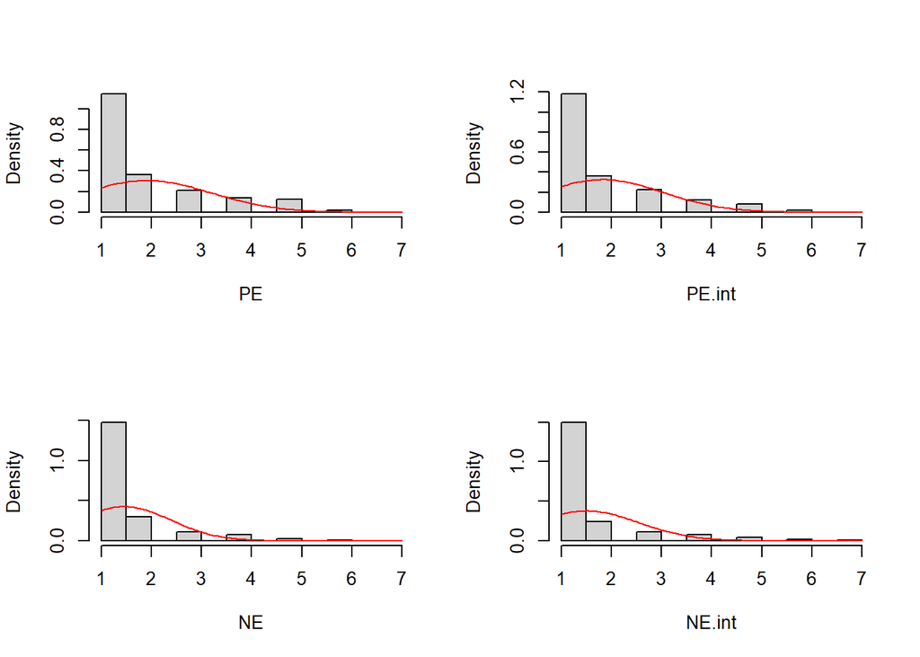

```
## $<NA>
## NULL
```

```r
mvn(data=Event[,event],univariatePlot="histogram")[4] # histogram events
```

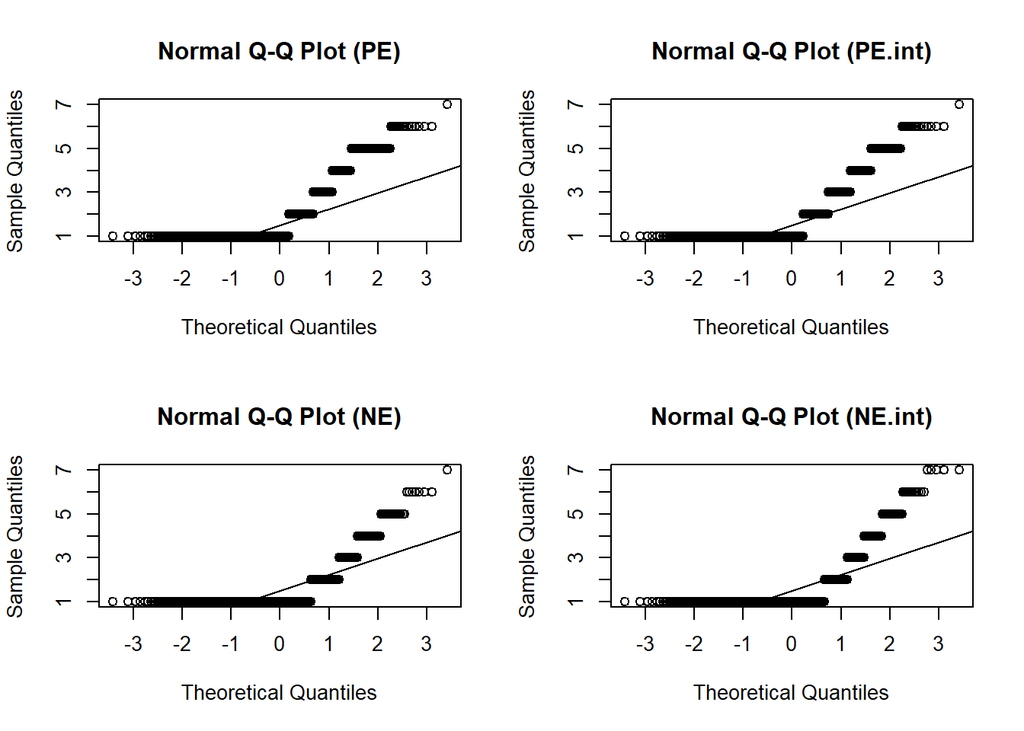

```
## $<NA>
## NULL
```

```r
mvn(data=Event[,event],univariatePlot="qqplot")[4] # qqnorm events
```

```r
# frequency of responses
for(ev in event){ cat("\n",ev,"\n"); print(summary(as.factor(ema[,ev]))) }
```

```
##
##  PE
##    1    2    3    4    5    6    7 NA's
##  908  290  169  110  101   20    1  438
##
##  PE.int
##    1    2    3    4    5    6    7 NA's
##  939  291  179  100   67   20    1  440
##
##  NE
##    1    2    3    4    5    6    7 NA's
## 1173  236   90   59   23    7    1  448
##
##  NE.int
##    1    2    3    4    5    6    7 NA's
## 1181  195   92   60   33   15    5  456
```

#### 2.2.1.2. ICC

Second, we evaluate the balance between inter- and intraindividual variability in each item score by computing the intraclass correlation coefficients (ICC) with the `itemsICC` function showed above. We can note that all ICCs are equal to or below .27, suggesting that **most variance is at level 1 (within)** but there is still substantial interindividual variability to consider multilevel modeling.

```r
itemsICC(data=Event,items=event)
```

```
## PE ICC = 0.264
## PE.int ICC = 0.197
## NE ICC = 0.197
## NE.int ICC = 0.159
```

#### 2.2.1.3. Correlations

Third, we visualize the correlation matrices of event item scores with the `corr.matrices` function showed above, also considering the correlations between event and mood items. As done in section 2.1.1.3, three matrices are generated:

1. The **pooled matrix** showing the correlations across all observations, that are considered as they were independent. We can note that correlations are in the expected directions, with each event and the corresponding intensity item being strongly correlated. However, weak-to-almost-null correlations are estimated between positive and negative event items, whereas only the latter are moderately correlated with mood dimensions (i.e., `HT` and `CA`, but not `EA`), although weak positive correlations are estimated between positive events and `HT`.

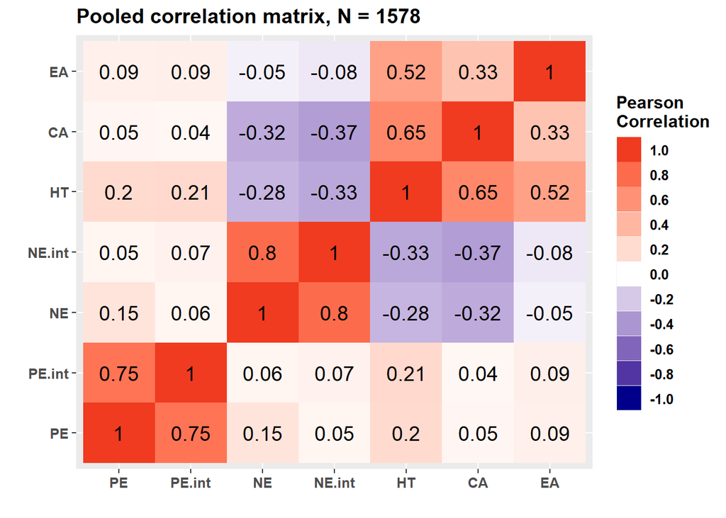

```r
corr.matrices(data=ema,vars=c("HT","CA","EA",event),matrix.type="pooled")
```

2. The **level-2 matrix** showing the correlations among the aggregated item scores, computed as the mean score for each participant, and thus reflecting the **between-individual covariance** between item scores. We can note that correlations between each event and the corresponding intensity item are quite similar to those shown in the pooled matrix above. In contrast, correlations between positive and negative event ratings shifted from almost null values to moderately positive correlations, suggesting that participants who tended to report more positive events also reported more negative events, and viceversa. Coherently with the pooled matrix, moderate negative correlations with mood items (i.e., `HT` and `CA`, but not `EA`) are only shown by negative events.

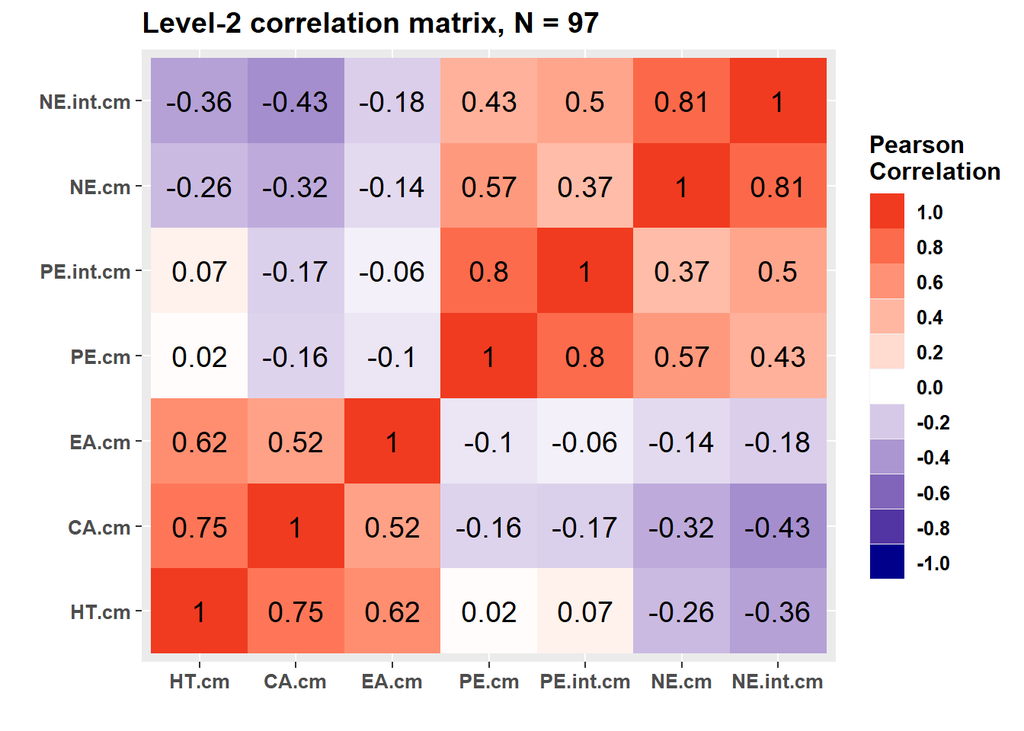

```r
corr.matrices(data=ema,vars=c("HT","CA","EA",event),matrix.type="between")
```

3. The **level-1 matrix** showing the correlations among the person-mean-centered item scores, computed by subtracting the participant’s mean from each of her ratings, and thus reflecting the **within-individual covariance** between item scores. We can note that the correlations are quite similar to those shown in the pooled matrix above, with even stronger correlations between positive event items and `HT`, corroborating the idea that emotional events are mainly intraindividual variables.

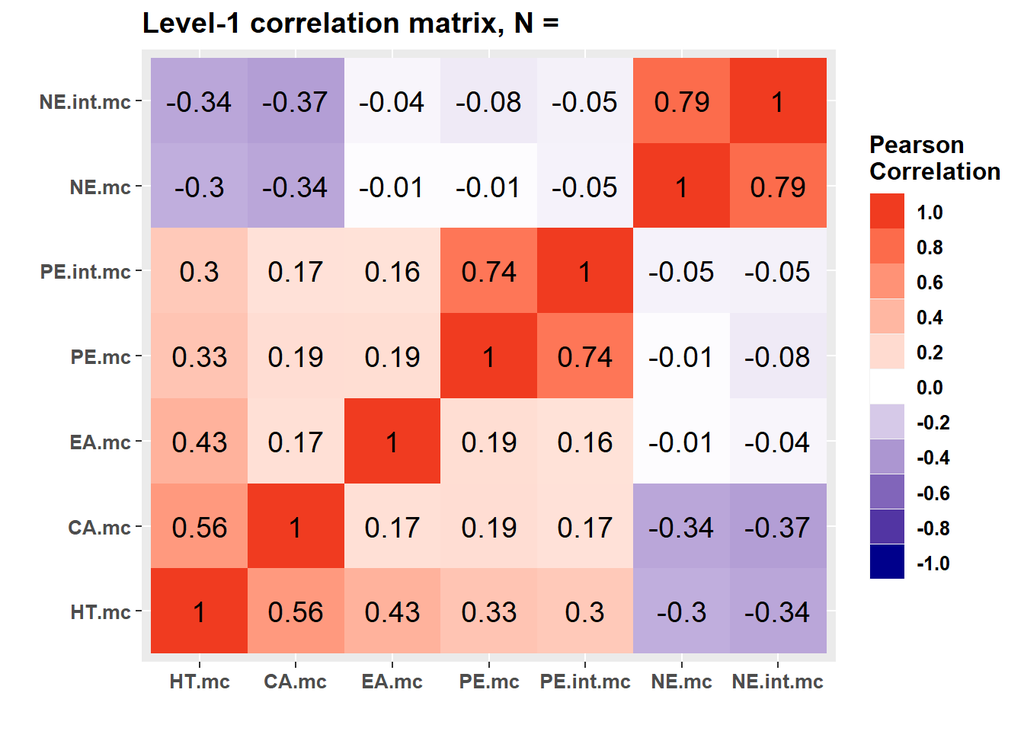

```r
corr.matrices(data=ema,vars=c("HT","CA","EA",event),matrix.type="within")
```

### 2.2.2. Inconsistencies

With event items, participants were instructed to rate both valence and intensity as 1 when no events occurred, whereas both items were presumably rated as > 1 when some events occurred. Here, we inspect the inconsistencies between event valence and intensity items for both positive and negative events. We can note a small number of inconsistencies from several participants.

```r
# PE inconsistencies between valence and intensity
nrow(ema[!is.na(ema$PE)&!is.na(ema$PE.int) & ema$PE>1 & ema$PE.int==1,]) # 58 with PE > 1 but PE.int = 1
```

```
## [1] 58
```

```r
nrow(ema[!is.na(ema$PE)&!is.na(ema$PE.int) & ema$PE==1 & ema$PE.int>1,]) # 27 with PE = 1 but PE.int > 1
```

```
## [1] 27
```

```r
nlevels(as.factor(as.character(ema[!is.na(ema$PE)&!is.na(ema$PE.int)
                                   & ((ema$PE>1 & ema$PE.int==1) | (ema$PE==1 & ema$PE.int>1)),"ID"]))) # 45 part. with 1+ inc.
```

```
## [1] 45
```

```r
nrow(ema[!is.na(ema$NE)&!is.na(ema$NE.int) & ema$NE>1 & ema$NE.int==1,]) # 38 with NE > 1 but NE.int = 1
```

```
## [1] 38
```

```r
nrow(ema[!is.na(ema$NE)&!is.na(ema$NE.int) & ema$NE==1 & ema$NE.int>1,]) # 23 with NE = 1 but PE.int > 1
```

```
## [1] 23
```

```r
nlevels(as.factor(as.character(ema[!is.na(ema$NE)&!is.na(ema$NE.int)
                                   & ((ema$NE>1 & ema$NE.int==1) | (ema$NE==1 & ema$NE.int>1)),"ID"]))) # 35 part. with 1+ inc.
```

```
## [1] 35
```

### 2.2.3. Aggregated scores

Due to the strongly skewed distributions of event item scores, their variability being mainly at the intraindividual level and the inconsistencies highlighted above, we do not compute MCFA-based and reliability indices to support the aggregation of event items by averaging item ratings. That is, we question the adequacy of our initial idea of considering these variables as ordinal/continuous, but we proceed by **dychotomizing** them. More specifically, we **create two dichotomic variables** `PosEv` and `NegEv` with possible scores 0 (both valence and intensity = 1) or 1 (either valence or intensity > 1).

```r
# PosEv: 0 if both valence and intensity = 1, 1 otherwise
ema[(!is.na(ema$PE) & ema$PE==1) | (!is.na(ema$PE.int) & ema$PE.int==1),"PosEv"] <- 0
ema[(!is.na(ema$PE) & ema$PE>1) | (!is.na(ema$PE.int) & ema$PE.int>1),"PosEv"] <- 1

# NegEv: 0 if both valence and intensity = 1, 1 otherwise
ema[(!is.na(ema$NE) & ema$NE==1) | (!is.na(ema$NE.int) & ema$NE.int==1),"NegEv"] <- 0
ema[(!is.na(ema$NE) & ema$NE>1) | (!is.na(ema$NE.int) & ema$NE.int>1),"NegEv"] <- 1

# summary
ema[,c("PosEv","NegEv")] <- lapply(ema[,c("PosEv","NegEv")],as.factor)
summary(ema[,c("PE","PE.int","PosEv","NE","NE.int","NegEv")])
```

```
##        PE            PE.int       PosEv           NE            NE.int
##  Min.   :1.000   Min.   :1.000   0   :881   Min.   :1.000   Min.   :1.000
##  1st Qu.:1.000   1st Qu.:1.000   1   :718   1st Qu.:1.000   1st Qu.:1.000
##  Median :1.000   Median :1.000   NA's:438   Median :1.000   Median :1.000
##  Mean   :1.918   Mean   :1.828              Mean   :1.457   Mean   :1.504
##  3rd Qu.:3.000   3rd Qu.:2.000              3rd Qu.:2.000   3rd Qu.:2.000
##  Max.   :7.000   Max.   :7.000              Max.   :7.000   Max.   :7.000
##  NA's   :438     NA's   :440                NA's   :448     NA's   :456
##   NegEv
##  0   :1151
##  1   : 440
##  NA's: 446
##
##
##
##
```

```r
# removing raw item scores
ema[,c("PE","PE.int","NE","NE.int")] <- NULL
```

# 3. Descriptives

Here, descriptive statistics are computed on the selected subsample (N = 97) using the following functions:

**`multidesc`**

```r
#' @title Printing descriptive statistics of multilevel variables
#' @param datasets = list of datasets to be used: occasion, block, between, gng
#' @param EMA = ESM and HRV data
#' @param GNG = GNG data
#' @param betw = between-only variables
multidesc <- function(datasets=NA,
                      EMA=c("RMSSD","PI","HT","CA","EA"),
                      GNG=c("RT","ICV","NoGo.ACC","Go.ACC"),
                      betw=NA){ require(Rmisc); require(lme4)

  # HRV and ESM data
  out <- data.frame(Measure=EMA[1],
                    N=summarySE(datasets[[1]],EMA[1],na.rm=TRUE)[,2],
                    Mean=paste(round(summarySE(datasets[[1]],EMA[1],na.rm=TRUE)[,3],2)," (",
                               round(summarySE(datasets[[1]],EMA[1],na.rm=TRUE)[,4],2),")",sep=""))
  for(i in 2:length(EMA)){
    out <- rbind(out,
                 data.frame(Measure=EMA[i],
                            N=summarySE(datasets[[1]],EMA[i],na.rm=TRUE)[,2],
                            Mean=paste(round(summarySE(datasets[[1]],EMA[i],na.rm=TRUE)[,3],2)," (",
                                       round(summarySE(datasets[[1]],EMA[i],na.rm=TRUE)[,4],2),")",sep="")))}

  # GNG data
  for(i in 1:length(GNG)){
    out <- rbind(out,
                 data.frame(Measure=GNG[i],
                            N=summarySE(datasets[[2]],GNG[i],na.rm=TRUE)[,2],
                            Mean=paste(round(summarySE(datasets[[2]],GNG[i],na.rm=TRUE)[,3],2)," (",
                                       round(summarySE(datasets[[2]],GNG[i],na.rm=TRUE)[,4],2),")",sep="")))}
  # number of considered trials
  out[out$Measure=="NoGo.ACC","N"] <- nrow(datasets[[4]][datasets[[4]]$TrialType=="No-go",])
  out[out$Measure=="Go.ACC"|out$Measure=="RT","N"] <- nrow(datasets[[4]][datasets[[4]]$TrialType=="Go",])

  # PrelQS data
  for(i in 1:length(betw)){
    out <- rbind(out,
                 data.frame(Measure=betw[i],
                            N=summarySE(datasets[[3]],betw[i],na.rm=TRUE)[,2],
                            Mean=paste(round(summarySE(datasets[[3]],betw[i],na.rm=TRUE)[,3],2)," (",
                                       round(summarySE(datasets[[3]],betw[i],na.rm=TRUE)[,4],2),")",sep="")))}

  # ICC
  out$ICC <- NA
  for(i in 1:length(EMA)){
    m <- lmer(formula=gsub("var",EMA[i],"var~(1|ID)"),data=datasets[[1]]) # VAR_between / (VAR_between + VAR_within)
    out[out$Measure==EMA[i],"ICC"] <- round(as.data.frame(VarCorr(m))[1,4]/
                                              (as.data.frame(VarCorr(m))[1,4]+as.data.frame(VarCorr(m))[2,4]),2)}
  for(i in 1:length(GNG)){
    m <- lmer(formula=gsub("var",GNG[i],"var~(1|ID)"),data=datasets[[2]]) # VAR_between / (VAR_between + VAR_within)
    out[out$Measure==GNG[i],"ICC"] <- round(as.data.frame(VarCorr(m))[1,4]/
                                              (as.data.frame(VarCorr(m))[1,4]+as.data.frame(VarCorr(m))[2,4]),2)}
  rownames(out) <- gsub(".cm","",rownames(out))
  return(out)}
```

Reports Mean (SD) and intraclass correlation coefficients (ICCs) of the included variables

**`multicorr`**

```r
#' @title Compute inter and intraindividual correlations between multilevel variables
#' @param datasets = list of datasets to be used: [[1]] occasion-by occasion, [[2]] = block, [[3]] = between, [[4]] = gng
#' @param EMA = ESM and HRV data
#' @param GNG = GNG data
#' @param betw = between-only variables
multicorr <- function(datasets=list(ema,block,between,gng),
                      EMA=c("RMSSD","HR","HT","TA","EA"),
                      GNG=c("RT","ICV","NoGo.ACC","Go.ACC"),
                      betw=c("DERS.tot","BIS.tot")){ require(Hmisc); require(dplyr); require(Rmisc)

  # between-subjects correlations (all variables)
  out.b <- rcorr(as.matrix(datasets[[3]][,c(paste(EMA,".cm",sep=""),GNG,betw)]), type = "pearson")
  rb <- round(out.b$r,2)
  rb[lower.tri(rb)] <- NA

  # within-participant correlations (HRV and ESM deviations from individual mean)
  out.w <- rcorr(as.matrix(datasets[[1]][,paste(EMA,".dm",sep="")]), type = "pearson")
  rw <- round(out.w$r,2)
  rw[upper.tri(rw)] <- NA

  # computing HRV and ESM deviations from daily mean
  dd.esm <- datasets[[1]] %>%
  group_by(ID,day) %>% # grouping by ID and day
  mutate(PI.md=mean(na.omit(PI)), HR.md=mean(na.omit(HR)), RMSSD.md=mean(na.omit(RMSSD)), # daily means
         RMSSDcv.md=mean(na.omit(RMSSDcv)),HT.md=mean(na.omit(HT)),EA.md=mean(na.omit(EA)),
         TA.md=mean(na.omit(TA)),
         PI.dd=PI.md-PI.cm,HR.dd=HR.md-HR.cm, RMSSD.dd=RMSSD.md-RMSSD.cm,RMSSDcv.dd=RMSSDcv.md-RMSSDcv.cm, # daily deviations
         HT.dd=HT.md-HT.cm,EA.dd=EA.md-EA.cm,TA.dd=TA.md-TA.cm,)

  GNGdata <- datasets[[4]]
  dd.gng <- cbind(summarySE(GNGdata[GNGdata$TrialType=="Go",],measurevar="ACC",groupvars=c("ID","day"))[,c("ID","day","ACC")],
                  summarySE(GNGdata[GNGdata$TrialType=="No-go",],measurevar="ACC",groupvars=c("ID","day"))[,"ACC"],
                  summarySE(GNGdata[GNGdata$TrialType=="Go" & (GNGdata$ACC==1 | is.na(GNGdata$ACC)),],
                            measurevar="RT",groupvars=c("ID","day"))[,c("RT","sd")]) # keep RT.sd
  colnames(dd.gng)[3:6] <- c("Go.ACC.md","NoGo.ACC.md","RT.md","RT.sd.md")
  dd.gng$ICV.md <- dd.gng$RT.sd.md/dd.gng$RT.md # ICV as RT.sd / mean RT
  dd.gng <- plyr::join(dd.gng,between[,c("ID",GNG)],by="ID") # attaching individual means
  dd.gng$NoGo.ACC.dd <- dd.gng$NoGo.ACC.md - dd.gng$NoGo.ACC # computing daily deviations
  dd.gng$ICV.dd <- dd.gng$ICV.md - dd.gng$ICV
  dd.gng$RT.dd <- dd.gng$RT.md - dd.gng$RT
  dd.gng$Go.ACC.dd <- dd.gng$Go.ACC.md - dd.gng$Go.ACC

  # joining dd.ema and dd.gng and computing within-participant correlation (HRV, ESM and GNG daily deviations)
  # nrow(dd.gng)==nrow(dd.esm[dd.esm$within.day==1,]) # sanity check
  dd <- plyr::join(dd.gng,dd.esm[dd.esm$within.day==1,],by=c("ID","day"),type="full")
  out.dd <- rcorr(as.matrix(dd[,c(paste(EMA,".dd",sep=""),paste(GNG,".dd",sep=""))]),type="pearson")
  rdd <- round(out.dd$r,2)
  rdd[upper.tri(rdd)] <- NA
  rdd <- rdd[(nrow(rdd)-3):nrow(rdd),]

  # filling rb empty cells
  rb[1:length(EMA),1:length(EMA)][lower.tri(rb[1:length(EMA),1:length(EMA)])] <- rw[lower.tri(rw)]
  rb[(length(EMA)+1):(length(EMA)+length(GNG)),1:length(EMA)] <- rdd[,1:length(EMA)]
  rb[(length(EMA)+1):(length(EMA)+length(GNG)),
     (length(EMA)+1):(length(EMA)+length(GNG))][lower.tri(rb[(length(EMA)+1):(length(EMA)+length(GNG)),
                                                             (length(EMA)+1):(length(EMA)+length(GNG))])] <-
    rdd[,(length(EMA)+1):(length(EMA)+length(GNG))][lower.tri(rdd[,(length(EMA)+1):(length(EMA)+length(GNG))])]

  out <- rb
  rownames(out) <- gsub(".cm","",rownames(out))

  return(t(out))}
```

Computes inter and intraindividual correlations between the included variables.

## 3.2. Descriptives

```r
# desc <- multidesc(datasets=list(ema,block,between,gng))
```

## 3.3. Univariate distributions

## 3.4. Correlations

## 3.5. Bivariate distributions

# 4. Covariate selection

# 5. References

- Hox, J. J. (2010). Multilevel Analysis: Techniques and Applications (2nd ed.). Routledge.
- Jak, S., & Jorgensen, T. D. (2017). Relating Measurement Invariance, Cross-Level Invariance, and Multilevel Reliability. Frontiers in Psychology, 8(OCT), 1–9. https://doi.org/10.3389/fpsyg.2017.01640
- Menghini, L., Pastore, M., & Balducci, C. (2022). Workplace stress in real time: Three parsimonious scales for the experience sampling measurement of stressors and strain at work. European Journal of Psychological Assessment. Advanced online publication. https://doi.org/10.1027/1015-5759/a000725 [full text](https://www.researchgate.net/publication/362475778_Workplace_Stress_in_Real_Time_Three_Parsimonious_Scales_for_the_Experience_Sampling_Measurement_of_Stressors_and_Strain_at_Work)
- Wilhelm, P., & Schoebi, D. (2007). Assessing mood in daily life: Structural validity, sensitivity to change, and reliability of a short-scale to measure three basic dimensions of mood. European Journal of Psychological Assessment, 23(4), 258–267. https://doi.org/10.1027/1015-5759.23.4.258

## 5.1 R packages

Auguie, Baptiste. 2017. *gridExtra: Miscellaneous Functions for "Grid" Graphics*. https://CRAN.R-project.org/package=gridExtra.

Bates, Douglas, Martin Mächler, Ben Bolker, and Steve Walker. 2015. “Fitting Linear Mixed-Effects Models Using lme4.” *Journal of Statistical Software* 67 (1): 1–48. https://doi.org/10.18637/jss.v067.i01.

Bates, Douglas, Martin Maechler, Ben Bolker, and Steven Walker. 2022. *Lme4: Linear Mixed-Effects Models Using Eigen and S4*. https://github.com/lme4/lme4/.

Harrell, Frank E, Jr. 2022. *Hmisc: Harrell Miscellaneous*. https://hbiostat.org/R/Hmisc/.

Hope, Ryan M. 2022. *Rmisc: Ryan Miscellaneous*. https://CRAN.R-project.org/package=Rmisc.

Korkmaz, Selcuk, Dincer Goksuluk, and Gokmen Zararsiz. 2014. “MVN: An r Package for Assessing Multivariate Normality.” *The R Journal* 6 (2): 151–62. https://journal.r-project.org/archive/2014-2/korkmaz-goksuluk-zararsiz.pdf.

———. 2021. *MVN: Multivariate Normality Tests*. https://CRAN.R-project.org/package=MVN.

R Core Team. 2022. *R: A Language and Environment for Statistical Computing*. Vienna, Austria: R Foundation for Statistical Computing. https://www.R-project.org/.

Rosseel, Yves. 2012. “lavaan: An R Package for Structural Equation Modeling.” *Journal of Statistical Software* 48 (2): 1–36. https://doi.org/10.18637/jss.v048.i02.

Rosseel, Yves, Terrence D. Jorgensen, and Nicholas Rockwood. 2022. *Lavaan: Latent Variable Analysis*. https://lavaan.ugent.be.

Wickham, Hadley. 2007. “Reshaping Data with the reshape Package.” *Journal of Statistical Software* 21 (12): 1–20. http://www.jstatsoft.org/v21/i12/.

———. 2011. “The Split-Apply-Combine Strategy for Data Analysis.” *Journal of Statistical Software* 40 (1): 1–29. https://www.jstatsoft.org/v40/i01/.

———. 2016. *Ggplot2: Elegant Graphics for Data Analysis*. Springer-Verlag New York. https://ggplot2.tidyverse.org.

———. 2020. *Reshape2: Flexibly Reshape Data: A Reboot of the Reshape Package*. https://github.com/hadley/reshape.

———. 2022. *Plyr: Tools for Splitting, Applying and Combining Data*. https://CRAN.R-project.org/package=plyr.

Wickham, Hadley, Winston Chang, Lionel Henry, Thomas Lin Pedersen, Kohske Takahashi, Claus Wilke, Kara Woo, Hiroaki Yutani, and Dewey Dunnington. 2022. *Ggplot2: Create Elegant Data Visualisations Using the Grammar of Graphics*. https://CRAN.R-project.org/package=ggplot2.